# Research Proposal: Modeling Daily Parking Ticket Counts in Milwaukee

### John Eckberg & Josiah Mathews

## Overview

[Milwaukee plans 65,000 more parking tickets, longer meter hours to fill transportation budget gap](https://www.jsonline.com/story/news/local/milwaukee/2025/10/21/milwaukee-aims-for-550k-parking-tickets-longer-meter-hours-in-2026/86817755007/) The city of Milwaukee relies on parking ticket revenue in order to fill budget gaps, a pressing issue given the [current deficit](https://urbanmilwaukee.com/2025/03/12/mke-county-county-faces-47-million-2026-budget-deficit/) the county is facing. This project plans to examine how daily parking ticket activity in Milwaukee varies across time and environmental conditions. Using parking citation records obtained through a Freedom of Information Act request (2014–2022), I propose to model daily ticket counts and evaluate whether temporal, weather, and holiday-related factors explain variation in enforcement volume.

## Research Question

What is the daily rate of parking tickets issued in Milwaukee, and which factors most strongly influence that rate (if any)? In particular, I propose to test whether day of week, month/seasonality, holidays, and precipitation are associated with higher or lower daily ticket counts, including by citation type.

## Hypothesis

- Null Hypothesis: day of week, month/seasonality, holidays, and precipitation do not affect daily ticket counts.
- Alternative Hypothesis: at least one temporal or environmental factor affects daily ticket counts.

## Data Sources

- **Parking citations:** Milwaukee parking ticket records, initially loaded for 2014, with fields including `ISSUENO`, `ISSUEDATE`, `LOCATIONDESC1`, and `VIODESCRIPTION`.
- **Holiday data:** U.S. holiday dates (2004–2021) pulled from Kaggle to identify atypical traffic/parking demand days.
- **Weather data:** Open-Meteo daily weather for Milwaukee, including maximum temperature, minimum temperature, precipitation, and snowfall.

## Method

The analysis would likely focus on a geographically meaningful subset of Milwaukee (e.g., downtown, Lower East Side, Deer District). Because the response variable is a daily count, I propose that the initial model choice would be a Poisson regression GLM.

### Currently Planned Features

- **Calendar effects:** day of week, month, weekend indicator, and potential seasonal terms.
- **Cyclical time encoding:** sine/cosine transforms for month and day-of-week to preserve circular structure.
- **Holiday effects:** binary `is_holiday` indicator, one-hot encoding for major holiday names.
- **Weather exposure:** `max_temp`, `min_temp`, `precipitation`, and `snowfall`; optional threshold features (e.g., heavy precipitation day).
- **Autocorrelation:** lagged ticket count features (e.g., 1-day and 7-day lags) and short rolling averages.

```python
import pandas as pd
import geopandas as gpd
import plotly.express as px
```

### Initial Visualization

Loading and Preprocessing Ticket Data Load the raw 2020 ticket dataset and prepare dates and columns.

```python
# load tickets
tickets = pd.read_excel(
    r"C:/Users/eckbergj/.vscode/Milwaukee-Ticket-Data-Analysis/data/tickets_csv/2020 parking citations issued open records request.xlsx"
)

# format dates & standardize columns
tickets['DATE'] = pd.to_datetime(tickets['ISSUEDATE'])
tickets = tickets.rename(columns={"LOCATIONDESC1": "LOCATION", "ISSUENO": "ISSUENUM"})

# keep DATE as index for timeseries access later
tickets.set_index('DATE', inplace=True)
tickets.head()
```

| DATE | ISSUENUM | ISSUEDATE | LOCATION | VIODESCRIPTION |
| --- | --- | --- | --- | --- |
| 2020-01-01 | 118673354 | 2020-01-01 | 1405 W GREENFIELD AV | PARKING PROHIBITED BY OFFICIAL SIGN |
| 2020-01-01 | 118861702 | 2020-01-01 | 119 W NATIONAL AV | PARKING PROHIBITED BY OFFICIAL SIGN |
| 2020-01-01 | 118918472 | 2020-01-01 | 1858 N COMMERCE ST | UNREGISTERED/ IMPROPERLY REGISTERED VEHICLE |
| 2020-01-01 | 118673446 | 2020-01-01 | 2219 N FARWELL AV | OBSTRUCTING BUS LOADING ZONE |
| 2020-01-01 | 118850141 | 2020-01-01 | 6423 W BRADLEY RD | FAILURE TO DISPLAY CURRENT REGISTRATION |

```python
# show types of viodescription
tickets['VIODESCRIPTION'].value_counts()
```

```
VIODESCRIPTION
METER PARKING VIOLATION                    70643
NIGHT PARKING                              50717
PARKING PROHIBITED BY OFFICIAL SIGN        26115
NIGHT PARKING - WRONG SIDE                 23204
SNOW EMERGENCY                             17070
                                           ...
PARKED ON SERVICE DRIVE ADJACENT TO HWY        4
NIGHT PARKING (OPEN BUSINESS IN BLOCK)         3
PARKED ON BRIDGES VIADUCTS OR UNDERPASS        2
TOW AWAY VIOLATION - STREET SWEEPING           1
PARKED IN EXCESS OF 4 HOURS PROHIBITED         1
Name: count, Length: 64, dtype: int64
```

Geocoding using ArcGIS Address Points To efficiently geocode hundreds of thousands of addresses, we map ticket locations to coordinates from Milwaukee's ArcGIS address dataset.

```python
# load the pre-cleaned address points data from city for geocoding
milwaukee = pd.read_csv("data/Address_Points_Clean.csv")

# since the geometry was saved to CSV, it is loaded as a string (WKT format).
# we use GeoPandas to convert it back to actual geometry objects to access .x and .y
milwaukee['geometry'] = gpd.GeoSeries.from_wkt(milwaukee['geometry'])

# build quick lookup dictionary mapping address -> geometry (x/y coordinates)
mke_dict = dict(zip(milwaukee['FullAddr'], milwaukee['geometry']))
missing_set = set()

def geocode_lat(location):
    if location in mke_dict:
        return mke_dict[location].x
    else:
        missing_set.add(location)
        return None

def geocode_lng(location):
    if location in mke_dict:
        return mke_dict[location].y
    else:
        missing_set.add(location)
        return None

tickets["Lat"] = tickets["LOCATION"].apply(geocode_lat)
tickets["Lng"] = tickets["LOCATION"].apply(geocode_lng)

# count unrecognized addresses (we will defer dropping them until AFTER the fallback step)
na_num = tickets['Lat'].isna().sum()
print(f"Total Unrecognized Addresses (Exact Match): {na_num}")
print(f"Total Exactly Geocoded Tickets: {len(tickets) - na_num}")
```

```
Total Unrecognized Addresses (Exact Match): 189836
Total Exactly Geocoded Tickets: 102403
```

EDA of Unrecognized Addresses There is a huge drop in parsed tickets during geocoding. The current model demands an exact string match between the recorded ticket location and our ArcGIS dataset. We can analyze the `missing_set` generated from the lookup function to discover if block-level tracking, intersections, or simple typos caused the mismatch.

```python
import re
import pandas as pd

# analyze the `missing_set` generated during geocoding
missing_df = pd.DataFrame(list(missing_set), columns=['OriginalAddress'])

# categorize the missing addresses based on common patterns
def categorize_missing(address):
    if not isinstance(address, str):
        return "Not a String/NaN"
    address = address.upper()
    if re.search(r'\bBLK\b|\bBLOCK\b|-', address):
        return "Block-Level Address"
    elif re.search(r'/|&|\bAND\b', address):
        return "Intersection"
    elif re.search(r'\bLOT\b', address):
        return "Parking Lot"
    else:
        return "Formatting/Typo/Other"

missing_df['Category'] = missing_df['OriginalAddress'].apply(categorize_missing)

# summary of missing categories
print("Summary of Unrecognized Address Types:")
print(missing_df['Category'].value_counts())
print("\n---")
print("\nSample of Block-Level Addresses:")
print(missing_df[missing_df['Category'] == 'Block-Level Address']['OriginalAddress'].head(5).tolist())
print("\nSample of Intersections:")
print(missing_df[missing_df['Category'] == 'Intersection']['OriginalAddress'].head(5).tolist())
print("\nSample of Formatting/Other Issues:")
print(missing_df[missing_df['Category'] == 'Formatting/Typo/Other']['OriginalAddress'].head(10).tolist())
```

```
Summary of Unrecognized Address Types:
Category
Formatting/Typo/Other    71199
Intersection                76
Block-Level Address         38
Parking Lot                 17
Not a String/NaN             1
Name: count, dtype: int64

---

Sample of Block-Level Addresses:
['1550 WI-32', '1914 WI-32', '2163 WI-38 TRUNK', '5315 WI-100', '2305 WI-32']

Sample of Intersections:
['542 ON 62ND (R/LOT)', '4638 W RICE WAY (R/LOT)', 'R/O 6029 N 41ST', '4321 N. SHERMAN BLVD R/LOT', 'LOT R/O 1525 N 24TH STREET']

Sample of Formatting/Other Issues:
['1307 N PROSPECT AV', '3217 N SUMMIT AV', '1216 S 22ND ST', '3300 W HIGHLAND AV', '810 W ARTHUR AV', '1040 E KEWAUNEE ST', '8212 W HOWARD AV', '2911 W HIGHLAND BL', '2219 N CAMBRIDGE AV', '730 N VEL R PHILLIPS AV']
```

```python
missing_df[missing_df['Category'] == 'Formatting/Typo/Other']['OriginalAddress'].head(30)
```

```
0                               1307 N PROSPECT AV
1                                 3217 N SUMMIT AV
2                                   1216 S 22ND ST
3                               3300 W HIGHLAND AV
4                                  810 W ARTHUR AV
5                               1040 E KEWAUNEE ST
6                                 8212 W HOWARD AV
7                               2911 W HIGHLAND BL
8                              2219 N CAMBRIDGE AV
9                          730 N VEL R PHILLIPS AV
10                                  512 E MASON ST
11                       3623 N PORT WASHINGTON AV
12                                2852 N SUMMIT AV
13                                3278 N SUMMIT AV
14                                  1232 N 10TH ST
```

[output cut: 16 more lines]

Block-Level Geocoding Fallback

Looks like a significant number of them are issues relating to missing house numbers in the city dataset? To handle this, we can extract the "100-block" (e.g., 1755 -> 1700 block) from both the tickets and our address points. By creating a dictionary that maps each "Street + 100-Block" to its average latitude and longitude, we can trade off exact mapping precision to properly capture these near-misses

```python
# parse Block Keys from the Master Address Dataset
def get_block_key(address):
    """
    Extracts the block and street string from an address:
    '1755 S 37TH ST' -> '17_S 37TH ST'
    '105 N MAIN ST' -> '1_N MAIN ST'
    '500 BLK N MAIN ST' -> '5_N MAIN ST'
    """
    if not isinstance(address, str):
        return None
    # Strip BLK and BLOCK for tickets formatting just in case
    addr = re.sub(r'\bBLK\b|\bBLOCK\b', '', address.upper())

    # match the starting numbers and the rest of the street name
    match = re.match(r'^\s*(\d+)\s+(.+)', addr)
    if match:
        house_num = match.group(1)
        street_name = match.group(2).strip()

        # floor the house number to the nearest 100 block (1755 // 100 = 17)
        # we store just '17' as the block identifier + the street
        block = int(house_num) // 100
        return f"{block}_{street_name}"
    return None

# duplicate the milwaukee dataset to extract X/Y properties
block_df = milwaukee.copy()
block_df['BlockKey'] = block_df['FullAddr'].apply(get_block_key)

# drop any that failed to parse a number (e.g. 'MAIN ST')
block_df = block_df.dropna(subset=['BlockKey', 'geometry'])

# The geometry column in the pandas DataFrame does not expose `.x` and `.y` directly.
# We must apply a function to the shapely Point objects to extract them.
block_df['lng'] = block_df['geometry'].apply(lambda pt: pt.x)
block_df['lat'] = block_df['geometry'].apply(lambda pt: pt.y)

# group by our new custom "17_S 37TH ST" keys, and average the lat/long for that entire block
grouped_blocks = block_df.groupby('BlockKey')[['lat', 'lng']].mean()

# convert to a dictionary: '17_S 37TH ST' -> (lat, lng)
mke_block_dict = grouped_blocks.to_dict('index')
print(f"Created fallback dictionary with {len(mke_block_dict)} street blocks.")

# try the Block keys on the missing Tickets
def fallback_lat(row):
    if pd.notna(row['Lat']): return row['Lat'] # Keep successful exact matches
    key = get_block_key(row['LOCATION'])
    if key in mke_block_dict:
        return mke_block_dict[key]['lat']
    return None

def fallback_lng(row):
    if pd.notna(row['Lng']): return row['Lng'] # Keep successful exact matches
    key = get_block_key(row['LOCATION'])
    if key in mke_block_dict:
        return mke_block_dict[key]['lng']
    return None

# apply the fallback lookup specifically checking empty coordinate columns
start_na = tickets['Lat'].isna().sum()
tickets['Lat'] = tickets.apply(fallback_lat, axis=1)
tickets['Lng'] = tickets.apply(fallback_lng, axis=1)
end_na = tickets['Lat'].isna().sum()

print(f"Reclaimed {start_na - end_na} tickets")

# export the final filtered data
tickets_final = tickets.dropna(subset=['Lat', 'Lng'])
tickets_final.to_csv("Tickets2020LatLngDropNa.csv")
print(f"\nFinal Geocoded Dataset Size: {len(tickets_final)}")
```

```
Created fallback dictionary with 31629 street blocks.
Reclaimed 89961 tickets

Final Geocoded Dataset Size: 192364
```

Mapping & Data Visualization Visualize spatial concentration and daily variations using Plotly Express mapbox visuals over street layouts.

```python
# filter plot df to look for patterns

# all
# plot_df = tickets_final.sort_values(by="ISSUEDATE").copy()
# only ticket type "METER PARKING VIOLATION "
plot_df = tickets_final[tickets_final['VIODESCRIPTION'] == "METER PARKING VIOLATION"].sort_values(by="ISSUEDATE").copy()

# only ticket type "NIGHT PARKING"
# plot_df = tickets_final[tickets_final['VIODESCRIPTION'] == "NIGHT PARKING"].sort_values(by="ISSUEDATE").copy()
```

```python
# animated interactive scatter map of tickets over time

# only include hover fields that actually exist in the dataframe
# cold probably rremove this?
hover_cols = [c for c in ["ISSUETIME", "VIOCODE", "VIODESCRIPTION", "LOCATION"] if c in plot_df.columns]

fig = px.scatter_mapbox(
    plot_df,
    lat="Lng",   # actual latitude values are stored in Lng
    lon="Lat",   # actual longitude values are stored in Lat
    hover_data=hover_cols,
    animation_frame="ISSUEDATE",
    title="Daily Ticket Dispersal - Milwaukee 2020",
)
fig.update_layout(
    mapbox_style="open-street-map",
    margin={"r":0,"t":40,"l":0,"b":0},
    mapbox_zoom=10,
    mapbox_center={"lat": 43.0389, "lon": -87.9065} # center around Milwaukee downtown
)
fig.show()
fig.write_html("milwaukee_tickets_2020_vis.html")
```

```python
# density MapBox showing general heatmap of tickets spanning the whole year
# using Plotly but with 'open-street-map' free tiles
heat = px.density_mapbox(
    tickets,
    lat='Lng',
    lon='Lat',
    radius=1, # Density spread
    title="Milwaukee Ticket Heatmap for 2020",
    opacity=0.5,
    template="presentation"
)
heat.update_layout(
    mapbox_style="open-street-map", # open-source tile layout
    mapbox_zoom=10,
    margin={"r":10,"t":60,"l":20,"b":10},
    mapbox_center={"lat": 43.0389, "lon": -87.9065}
)
heat.show()
```

```python
import pandas as pd
import requests
import kagglehub
import openpyxl
from pathlib import Path
import seaborn as sns
import matplotlib.pyplot as plt
```

## Full Pre-processing

```python
# Loading in the parking data [All Years now]  --  Runs in about 10 mins

#tickets_df = pd.read_excel("data/tickets_csv/2014_parking_citations_issued_open_records_request.xlsx")
data_dir = Path("data/tickets_csv")

tickets_dfs = []

for file in sorted(data_dir.glob("*.xlsx")):
    df = pd.read_excel(file)
    tickets_dfs.append(df)

tickets = pd.concat(tickets_dfs, ignore_index=True)

tickets.sample(5)
```

|  | ISSUENO | ISSUEDATE | LOCATIONDESC1 | VIODESCRIPTION |
| --- | --- | --- | --- | --- |
| 1828354 | 100623003 | 2016-12-17 | 2555 N 21ST ST | PARKING PROHIBITED BY OFFICIAL SIGN |
| 4685552 | 130364522 | 2022-07-29 | 1465 N FARWELL AV | NIGHT PARKING |
| 2718647 | 109723235 | 2018-06-05 | 6201 W KEEFE AVENUE PK | NIGHT PARKING |
| 677714 | 482524372 | 2015-01-24 | 2774 N MURRAY AVE | NIGHT PARKING |
| 2501019 | 107525762 | 2018-02-04 | 1224 E KANE PL | NIGHT PARKING DURING DPW OPERATION |

```python
tickets.info()
```

```
<class 'pandas.DataFrame'>
RangeIndex: 4865096 entries, 0 to 4865095
Data columns (total 4 columns):
 #   Column          Dtype
---  ------          -----
 0   ISSUENO         int64
 1   ISSUEDATE       datetime64[us]
 2   LOCATIONDESC1   object
 3   VIODESCRIPTION  str
dtypes: datetime64[us](1), int64(1), object(1), str(1)
memory usage: 148.5+ MB
```

```python
# load in holiday data (https://www.kaggle.com/datasets/donnetew/us-holiday-dates-2004-2021)

path = kagglehub.dataset_download("donnetew/us-holiday-dates-2004-2021")

print("Path to dataset files:", path)
```

```
Path to dataset files: C:\Users\eckbergj\.cache\kagglehub\datasets\donnetew\us-holiday-dates-2004-2021\versions\1
```

```python
#holidays_df = pd.read_csv("C:/Users/eckbergj/.vscode/Milwaukee-Ticket-Data-Analysis/data/US Holiday Dates (2004-2021).csv")
holidays_df = pd.read_csv("data/US Holiday Dates (2004-2021).csv")

holidays_df.head(10)
```

|  | Date | Holiday | WeekDay | Month | Day | Year |
| --- | --- | --- | --- | --- | --- | --- |
| 0 | 2004-07-04 | 4th of July | Sunday | 7 | 4 | 2004 |
| 1 | 2005-07-04 | 4th of July | Monday | 7 | 4 | 2005 |
| 2 | 2006-07-04 | 4th of July | Tuesday | 7 | 4 | 2006 |
| 3 | 2007-07-04 | 4th of July | Wednesday | 7 | 4 | 2007 |
| 4 | 2008-07-04 | 4th of July | Friday | 7 | 4 | 2008 |
| 5 | 2009-07-04 | 4th of July | Saturday | 7 | 4 | 2009 |
| 6 | 2010-07-04 | 4th of July | Sunday | 7 | 4 | 2010 |
| 7 | 2011-07-04 | 4th of July | Monday | 7 | 4 | 2011 |
| 8 | 2012-07-04 | 4th of July | Wednesday | 7 | 4 | 2012 |
| 9 | 2013-07-04 | 4th of July | Thursday | 7 | 4 | 2013 |

```python
# weather data (https://open-meteo.com/)  [extended from 2012 - 2022]
test_data = requests.get("https://archive-api.open-meteo.com/v1/archive?latitude=43.0389&longitude=-87.9065&start_date=2014-01-01&end_date=2022-12-31&daily=temperature_2m_max,temperature_2m_min,precipitation_sum,snowfall_sum&timezone=America%2FChicago")
test_data_json = test_data.json()

# minor cleaning of the weather data to get it into a dataframe
weather_df = pd.DataFrame(test_data_json['daily'])
weather_df['time'] = pd.to_datetime(weather_df['time'])
weather_df = weather_df.rename(columns={'time': 'date', 'temperature_2m_max': 'max_temp', 'temperature_2m_min': 'min_temp', 'precipitation_sum': 'precipitation','snowfall_sum': 'snowfall'})
weather_df.sample(10)
```

|  | date | max_temp | min_temp | precipitation | snowfall |
| --- | --- | --- | --- | --- | --- |
| 704 | 2015-12-06 | 5.4 | 1.7 | 0.0 | 0.00 |
| 1013 | 2016-10-10 | 16.6 | 12.8 | 0.0 | 0.00 |
| 2235 | 2020-02-14 | -10.2 | -22.8 | 0.0 | 0.00 |
| 2737 | 2021-06-30 | 26.5 | 17.8 | 3.2 | 0.00 |
| 2031 | 2019-07-25 | 28.4 | 18.3 | 0.3 | 0.00 |
| 615 | 2015-09-08 | 22.2 | 17.0 | 11.3 | 0.00 |
| 326 | 2014-11-23 | 7.3 | 4.9 | 11.9 | 0.00 |
| 625 | 2015-09-18 | 21.0 | 18.4 | 20.9 | 0.00 |
| 556 | 2015-07-11 | 21.2 | 16.5 | 2.9 | 0.00 |
| 1524 | 2018-03-05 | 2.5 | -0.5 | 3.5 | 2.38 |

```python
# clean and align date keys before joining
tickets_clean = tickets.copy()
holidays_clean = holidays_df.copy()
weather_clean = weather_df.copy()

# Datetime object
tickets_clean['join_date'] = pd.to_datetime(tickets_clean['ISSUEDATE'], errors='coerce').dt.normalize()
holidays_clean['join_date'] = pd.to_datetime(holidays_clean['Date'], errors='coerce').dt.normalize()
weather_clean['join_date'] = pd.to_datetime(weather_clean['date'], errors='coerce').dt.normalize()


# merge tickets with holidays and weather on a consistent datetime key
combined_tickets_and_holidays_df = pd.merge(
    tickets_clean,
    holidays_clean,
    how='left',      # SWITCHED from 'inner' to 'left' to keep all tickets, even those without a holiday match (-> 'NAN')
    on='join_date'
 )

combined_all_df = pd.merge(
    combined_tickets_and_holidays_df,
    weather_clean,
    how='left',
    on='join_date',
    suffixes=('_holiday', '_weather')
 )

# Dropping REDUNDANT columns from the joins and the Holiday data (since many become NAN, will grab the same date info later on)
combined_all_df = combined_all_df.drop(columns=['ISSUEDATE','Date','date','WeekDay', 'Month', 'Day', 'Year'])

# sample of the combined dataframe
combined_all_df[combined_all_df['Holiday'].notnull()].sample(5)
#combined_all_df.sample(5)
```

|  | ISSUENO | LOCATIONDESC1 | VIODESCRIPTION | join_date | Holiday | max_temp | min_temp | precipitation | snowfall |
| --- | --- | --- | --- | --- | --- | --- | --- | --- | --- |
| 2456646 | 106795441 | 5433 W MARTIN DR | NIGHT PARKING DURING DPW OPERATION | 2018-01-15 | Martin Luther King, Jr. Day | -2.9 | -7.9 | 5.0 | 3.43 |
| 4355439 | 126733994 | 319 E MENOMONEE ST | METER PARKING VIOLATION | 2021-11-24 | Thanksgiving Eve | 9.5 | 2.4 | 0.0 | 0.00 |
| 625060 | 481822843 | 1629 E ROYALL PL | PARKED IN EXCESS OF 2 HOURS PROHIBITED | 2014-12-24 | Christmas Eve | 3.2 | 1.6 | 1.4 | 0.00 |
| 3699529 | 119666783 | 2005 W JUNEAU AV | NIGHT PARKING | 2020-02-14 | Valentine’s Day | -10.2 | -22.8 | 0.0 | 0.00 |
| 1839604 | 100775905 | 2760 S DELAWARE AV | NIGHT PARKING | 2016-12-24 | Christmas Eve | 1.4 | 0.5 | 0.0 | 0.07 |

### Feature Engineering

```python
# Use Pandas DateTime to get WeekDay, Day (number), Month, Year from each ticket's join_date (ISSUEDATE)
combined_all_df['WeekDay'] = pd.to_datetime(combined_all_df['join_date'], errors='coerce').dt.day_name()
combined_all_df['Day'] = pd.to_datetime(combined_all_df['join_date'], errors='coerce').dt.day
combined_all_df['Month'] = pd.to_datetime(combined_all_df['join_date'], errors='coerce').dt.month
combined_all_df['Year'] = pd.to_datetime(combined_all_df['join_date'], errors='coerce').dt.year

combined_all_df.sample(5)
```

|  | ISSUENO | LOCATIONDESC1 | VIODESCRIPTION | join_date | Holiday | max_temp | min_temp | precipitation | snowfall | WeekDay | Day | Month | Year |
| --- | --- | --- | --- | --- | --- | --- | --- | --- | --- | --- | --- | --- | --- |
| 3367695 | 116237321 | 4541 W LEON TR | NIGHT PARKING | 2019-07-24 | NaN | 25.5 | 13.3 | 0.0 | 0.00 | Wednesday | 24 | 7 | 2019 |
| 1346319 | 489872121 | 725 N 13TH ST | IMPROPERLY DISPLAYED VEHICLE REGISTRATION | 2016-02-25 | NaN | 0.3 | -2.2 | 0.1 | 0.49 | Thursday | 25 | 2 | 2016 |
| 4240558 | 125484741 | 213 W HIGHLAND AV | METER PARKING VIOLATION | 2021-09-01 | NaN | 23.0 | 17.3 | 0.0 | 0.00 | Wednesday | 1 | 9 | 2021 |
| 4292390 | 126098700 | 1724 N ARLINGTON PL | NIGHT PARKING | 2021-10-07 | NaN | 19.3 | 17.2 | 9.4 | 0.00 | Thursday | 7 | 10 | 2021 |
| 3167463 | 114281112 | 2848 N 76TH ST | NIGHT PARKING | 2019-03-09 | NaN | 2.2 | -8.4 | 19.4 | 4.06 | Saturday | 9 | 3 | 2019 |

```python
# See what Violation categories can be made out of the data
combined_all_df.value_counts('VIODESCRIPTION')
```

```
VIODESCRIPTION
NIGHT PARKING                                1527527
METER PARKING VIOLATION                       810877
NIGHT PARKING - WRONG SIDE                    748186
PARKING PROHIBITED BY OFFICIAL SIGN           259562
IMPROPERLY DISPLAYED VEHICLE REGISTRATION     203366
                                              ...
TESTING IVR                                        2
TEST VIOLATION                                     1
PARKED IN RECREATIONAL AREA                        1
PARKED IN EXCESS OF 24 HOURS PROHIBITED            1
EXCEED 10-HOUR LIMIT AT METER                      1
Name: count, Length: 90, dtype: int64
```

```python
# Feature for  Winter Storm? Inclement Weather?  Threshold can be adjusted
combined_all_df['is_snow_emergency'] = ((combined_all_df['VIODESCRIPTION'].str.lower().str.contains('snow|emergency')) |      # in-line OR
                                        (combined_all_df['snowfall'] > 3.0)).astype(int)

# Heavy Rain?
combined_all_df['is_heavy_rain'] = (combined_all_df['precipitation'] > 2.0).astype(int)

# Meter Violation?
combined_all_df['is_meter_ticket'] = combined_all_df['VIODESCRIPTION'].str.lower().str.contains('meter').astype(int) # 1 = Meter Violation, 0 = Not a Meter Violation

# Night Violation?
combined_all_df['is_night_ticket'] = combined_all_df['VIODESCRIPTION'].str.lower().str.contains('night').astype(int) # 1 = Night Violation, 0 = Not a Night Violation

# Registration Violation?
combined_all_df['is_registration_ticket'] = combined_all_df['VIODESCRIPTION'].str.lower().str.contains('registration|unregistered').astype(int) # 1 = Registration Violation, 0 = Not a Registration Violation

# Time Violation ?
combined_all_df['is_time_ticket'] = combined_all_df['VIODESCRIPTION'].str.lower().str.contains('excess|hours|time').astype(int) # 1 = Time Violation, 0 = Not a Time Violation

# Weekend Violation?  Could add Friday as well if wanted
combined_all_df['is_weekend_ticket'] = combined_all_df['WeekDay'].str.lower().str.contains('saturday|sunday').astype(int) # 1 = Weekend Violation, 0 = Not a Weekend Violation
# is sunday
combined_all_df['is_sunday_ticket'] = (combined_all_df['WeekDay'].str.lower() == 'sunday').astype(int) # 1 = Sunday Violation, 0 = Not a Sunday Violation

# Create a binary holiday flag immediately after the merge
# If 'Holiday' is not null, it becomes 1. If it is null, it becomes 0.
combined_all_df['is_holiday'] = combined_all_df['Holiday'].notnull().astype(int)

combined_all_df[combined_all_df['is_holiday'] == 1].sample(8)
```

|  | ISSUENO | LOCATIONDESC1 | VIODESCRIPTION | join_date | Holiday | max_temp | min_temp | precipitation | snowfall | WeekDay | ... | Year | is_snow_emergency | is_heavy_rain | is_meter_ticket | is_night_ticket | is_registration_ticket | is_time_ticket | is_weekend_ticket | is_sunday_ticket | is_holiday |
| --- | --- | --- | --- | --- | --- | --- | --- | --- | --- | --- | --- | --- | --- | --- | --- | --- | --- | --- | --- | --- | --- |
| 2529663 | 107748185 | 1552 N 7TH ST | NIGHT PARKING - WRONG SIDE | 2018-02-14 | Valentine’s Day | 5.7 | -4.7 | 0.0 | 0.00 | Wednesday | ... | 2018 | 0 | 0 | 0 | 1 | 0 | 0 | 0 | 0 | 1 |
| 3616661 | 118871594 | 268 E MENOMONEE ST | METER PARKING VIOLATION | 2019-12-31 | New Year’s Eve | -0.7 | -5.5 | 4.1 | 2.87 | Tuesday | ... | 2019 | 0 | 1 | 1 | 0 | 0 | 0 | 0 | 0 | 1 |
| 1654331 | 493056373 | 5757 N 92ND ST | NIGHT PARKING - WRONG SIDE | 2016-09-03 | Labor Day Weekend | 21.6 | 18.3 | 0.0 | 0.00 | Saturday | ... | 2016 | 0 | 0 | 0 | 1 | 0 | 0 | 1 | 0 | 1 |
| 1655183 | 493129560 | 633 S 6TH ST | PARKING PROHIBITED BY OFFICIAL SIGN | 2016-09-05 | Labor Day | 25.3 | 20.4 | 0.0 | 0.00 | Monday | ... | 2016 | 0 | 0 | 0 | 0 | 0 | 0 | 0 | 0 | 1 |
| 635564 | 481961513 | 1716 E KENWOOD BLVD | NIGHT PARKING | 2014-12-31 | New Year’s Eve | -7.0 | -13.8 | 0.0 | 0.00 | Wednesday | ... | 2014 | 0 | 0 | 0 | 1 | 0 | 0 | 0 | 0 | 1 |
| 715749 | 482693466 | 1556 N FARWELL AVE | PARKED IN LOADING ZONE | 2015-02-14 | Valentine’s Day | -4.7 | -17.4 | 0.0 | 0.14 | Saturday | ... | 2015 | 0 | 0 | 0 | 0 | 0 | 0 | 1 | 0 | 1 |
| 1932708 | 101637384 | 4825 N 39TH ST | NIGHT PARKING | 2017-02-14 | Valentine’s Day | 9.2 | 0.2 | 0.1 | 0.00 | Tuesday | ... | 2017 | 0 | 0 | 0 | 1 | 0 | 0 | 0 | 0 | 1 |
| 1183409 | 488245096 | 2741 N 44TH ST | NIGHT PARKING - WRONG SIDE | 2015-11-25 | Thanksgiving Eve | 8.5 | 4.9 | 0.2 | 0.00 | Wednesday | ... | 2015 | 0 | 0 | 0 | 1 | 0 | 0 | 0 | 0 | 1 |

8 rows × 22 columns

```python
# Compressing into a Daily Format: Row per Day, with Ticket Counts and Weather/Holiday Features to be able to then predict the Daily Rate of parking tickets (and the features that affect that)
daily_summary_df = combined_all_df.groupby('join_date').agg(
    # Target Variable: COUNT of the total tickets issued that day
    total_tickets=('ISSUENO', 'count'),

    # Dataset Weather Features:
    max_temp = ('max_temp', 'max'),
    min_temp = ('min_temp', 'min'),
    precipitation = ('precipitation', 'max'),
    snowfall = ('snowfall', 'max'),
    is_snow_emergency = ('is_snow_emergency', 'max'),
    is_heavy_rain = ('is_heavy_rain', 'max'),

    # Calendar Features:
    WeekDay = ('WeekDay', 'first'),
    Year = ('Year', 'first'),
    Month = ('Month', 'first'),
    Day = ('Day', 'first'),
    is_weekend = ('is_weekend_ticket', 'max'),
    is_sunday = ('is_sunday_ticket', 'max'),
    is_holiday = ('is_holiday', 'max'),

    # Count up the number of each Binary Feature type per day!
    meter_tickets_count = ('is_meter_ticket', 'sum'),
    night_tickets_count = ('is_night_ticket', 'sum'),
    registration_tickets_count = ('is_registration_ticket', 'sum'),
    time_tickets_count = ('is_time_ticket', 'sum')
).reset_index()
```

```python
# add in LAGGED Snow Emergency Feature (if yesterday (or 2 days ago) was a snow emergency, does that affect the number of tickets issued today?)

# sort rows by date
daily_summary_df = daily_summary_df.sort_values('join_date').reset_index(drop=True)

daily_summary_df['is_snow_emergency_lag1'] = daily_summary_df['is_snow_emergency'].shift(1).fillna(0)  # Lag of 1 day ago
daily_summary_df['is_snow_emergency_lag2'] = daily_summary_df['is_snow_emergency'].shift(2).fillna(0)  # Lag of 2 days ago
#daily_summary_df['is_snow_emergency_lag3'] = daily_summary_df['is_snow_emergency'].shift(3).fillna(0)  # Lag of 3 days (72 hours after original snow emergency)

daily_summary_df.sample(10)
# daily_summary_df.describe()
```

|  | join_date | total_tickets | max_temp | min_temp | precipitation | snowfall | is_snow_emergency | is_heavy_rain | WeekDay | Year | ... | Day | is_weekend | is_sunday | is_holiday | meter_tickets_count | night_tickets_count | registration_tickets_count | time_tickets_count | is_snow_emergency_lag1 | is_snow_emergency_lag2 |
| --- | --- | --- | --- | --- | --- | --- | --- | --- | --- | --- | --- | --- | --- | --- | --- | --- | --- | --- | --- | --- | --- |
| 2858 | 2021-10-29 | 917 | 12.5 | 10.9 | 7.3 | 0.0 | 0 | 1 | Friday | 2021 | ... | 29 | 0 | 0 | 0 | 221 | 370 | 39 | 70 | 0.0 | 0.0 |
| 1058 | 2016-11-24 | 199 | 5.5 | 3.2 | 0.0 | 0.0 | 0 | 0 | Thursday | 2016 | ... | 24 | 0 | 0 | 1 | 0 | 0 | 120 | 6 | 0.0 | 0.0 |
| 131 | 2014-05-12 | 1446 | 16.4 | 9.5 | 5.0 | 0.0 | 0 | 1 | Monday | 2014 | ... | 12 | 0 | 0 | 0 | 533 | 467 | 113 | 109 | 0.0 | 0.0 |
| 3099 | 2022-06-27 | 637 | 23.8 | 14.9 | 0.0 | 0.0 | 0 | 0 | Monday | 2022 | ... | 27 | 0 | 0 | 0 | 106 | 314 | 53 | 38 | 0.0 | 0.0 |
| 1340 | 2017-09-02 | 1330 | 21.5 | 10.3 | 3.0 | 0.0 | 0 | 1 | Saturday | 2017 | ... | 2 | 1 | 0 | 1 | 99 | 981 | 103 | 43 | 0.0 | 0.0 |
| 2472 | 2020-10-08 | 1071 | 17.6 | 9.0 | 0.0 | 0.0 | 0 | 0 | Thursday | 2020 | ... | 8 | 0 | 0 | 0 | 418 | 0 | 0 | 180 | 0.0 | 0.0 |
| 1598 | 2018-05-18 | 1650 | 15.8 | 7.8 | 1.8 | 0.0 | 0 | 0 | Friday | 2018 | ... | 18 | 0 | 0 | 0 | 169 | 995 | 102 | 71 | 0.0 | 0.0 |
| 669 | 2015-11-01 | 176 | 13.1 | 9.5 | 0.0 | 0.0 | 0 | 0 | Sunday | 2015 | ... | 1 | 1 | 1 | 0 | 0 | 0 | 32 | 0 | 0.0 | 0.0 |
| 114 | 2014-04-25 | 1954 | 12.3 | 4.2 | 7.9 | 0.0 | 0 | 1 | Friday | 2014 | ... | 25 | 0 | 0 | 0 | 591 | 800 | 106 | 166 | 0.0 | 0.0 |
| 1845 | 2019-01-20 | 2076 | -11.5 | -17.1 | 0.0 | 0.0 | 0 | 0 | Sunday | 2019 | ... | 20 | 1 | 1 | 0 | 0 | 1933 | 18 | 11 | 1.0 | 1.0 |

10 rows × 21 columns

```python
# convert month and week features into cosine and sine transformations to capture cyclical nature
# month_sin, month_cos, weekday_sin, weekday_cos
daily_summary_df['month_sin'] = np.sin(2 * np.pi * daily_summary_df['Month'] / 12)
daily_summary_df['month_cos'] = np.cos(2 * np.pi * daily_summary_df['Month'] / 12)
# map WeekDay to integer
weekday_map = {'Monday': 0, 'Tuesday': 1, 'Wednesday': 2, 'Thursday': 3, 'Friday': 4, 'Saturday': 5, 'Sunday': 6}
daily_summary_df['WeekDay_num'] = daily_summary_df['WeekDay'].map(weekday_map)
daily_summary_df['weekday_sin'] = np.sin(2 * np.pi * daily_summary_df['WeekDay_num'] / 7)
daily_summary_df['weekday_cos'] = np.cos(2 * np.pi * daily_summary_df['WeekDay_num'] / 7)

# map day of month to cyclical features as well?
daily_summary_df['day_sin'] = np.sin(2 * np.pi * daily_summary_df['Day'] / 31)
daily_summary_df['day_cos'] = np.cos(2 * np.pi * daily_summary_df['Day'] / 31)
```

### Visualization & Statistical Testing (EDA)

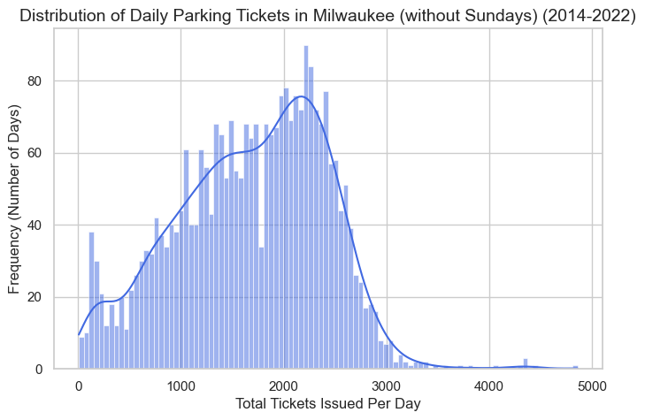

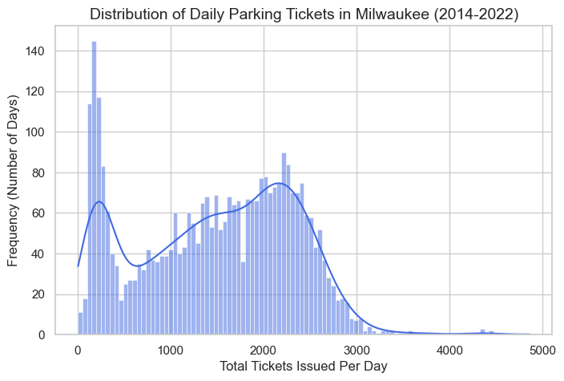

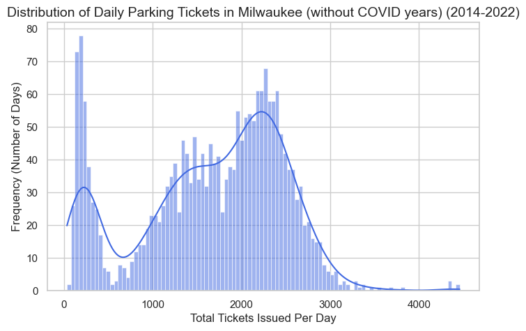

```python
sns.set_theme(style="whitegrid")

# drop the year 2020 and 2021 for the histogram to see if the distribution changes without the covid years (since they are likely outliers in terms of ticket counts)
daily_summary_no_covid_df = daily_summary_df[~daily_summary_df['Year'].isin([2020, 2021, 2022])]
daily_summary_no_sunday_df = daily_summary_df[~daily_summary_df['WeekDay'].isin(['Sunday'])]

# Histogram Plot of the Distribution of Total Daily Tickets to show Right Skewed Tail
plt.figure(figsize=(8, 5))
sns.histplot(daily_summary_no_sunday_df['total_tickets'], bins=100, kde=True, color='royalblue')


plt.title("Distribution of Daily Parking Tickets in Milwaukee (without Sundays) (2014-2022)", fontsize=14)
plt.xlabel("Total Tickets Issued Per Day", fontsize=12)
plt.ylabel("Frequency (Number of Days)", fontsize=12)
plt.show()

# plot with sundays included as well to see the difference
plt.figure(figsize=(8, 5))
sns.histplot(daily_summary_df['total_tickets'], bins=100, kde=True, color='royalblue')
plt.title("Distribution of Daily Parking Tickets in Milwaukee (2014-2022)", fontsize=14)
plt.xlabel("Total Tickets Issued Per Day", fontsize=12)
plt.ylabel("Frequency (Number of Days)", fontsize=12)
plt.show()

# plot without covid years
plt.figure(figsize=(8, 5))
sns.histplot(daily_summary_no_covid_df['total_tickets'], bins=100, kde=True, color='royalblue')
plt.title("Distribution of Daily Parking Tickets in Milwaukee (without COVID years) (2014-2022)", fontsize=14)
plt.xlabel("Total Tickets Issued Per Day", fontsize=12)
plt.ylabel("Frequency (Number of Days)", fontsize=12)
plt.show()
```

Temporal (Time) Features

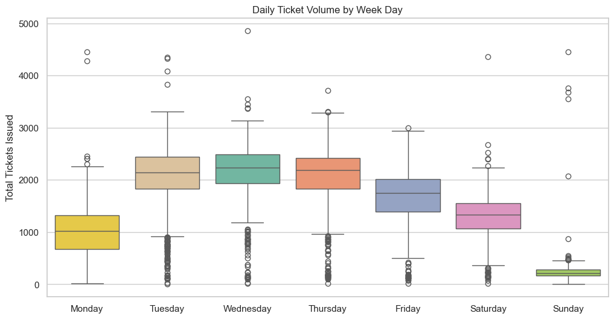

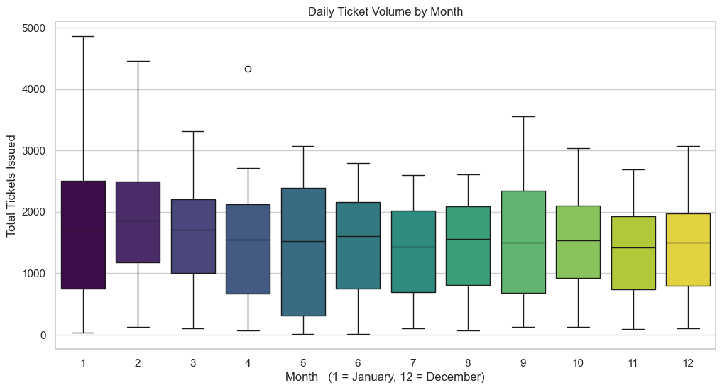

```python
# WeekDay	Year	Month	Day	 is_weekend	is_holiday
temporal_cols = ['WeekDay', 'Year', 'Month', 'Day', 'is_weekend', 'is_holiday']

# WeekDay vs. Total_Tickets (Daily Count) -> Cat. vs. Num - Boxplot
days_ordered = ['Monday', 'Tuesday', 'Wednesday', 'Thursday', 'Friday', 'Saturday', 'Sunday']
plt.figure(figsize=(12, 6))
sns.boxplot(x='WeekDay', y='total_tickets', order=days_ordered, data=daily_summary_df, hue='WeekDay', palette='Set2')
plt.title("Daily Ticket Volume by Week Day")
plt.xlabel("")
plt.ylabel("Total Tickets Issued")
plt.show()

# Month vs. Total_Tickets
plt.figure(figsize=(12, 6))
sns.boxplot(x='Month', y='total_tickets',  data=daily_summary_df, hue='Month', palette='viridis', legend=False)
plt.title("Daily Ticket Volume by Month")
plt.xlabel("Month   (1 = January, 12 = December)")
plt.ylabel("Total Tickets Issued")
plt.show()
```

Sunday is very CLEARLY the least Ticketed day, followed by Monday!

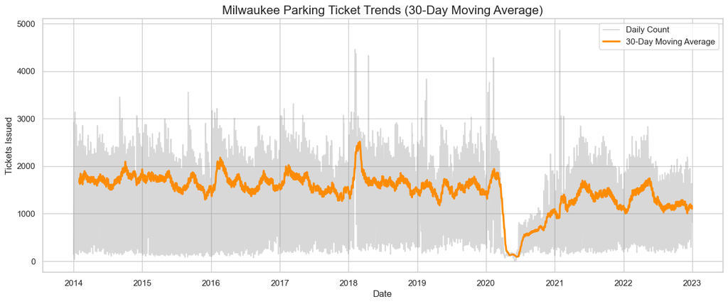

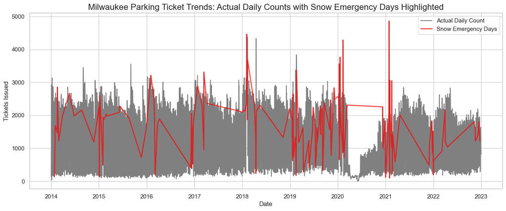

```python
# Dataframe is sorted chronologically
daily_summary_df = daily_summary_df.sort_values('join_date').reset_index(drop=True)

# Calculate the 30-day moving average  [a single day's ticket total and 29 days prior to that Averaged]
daily_summary_df['rolling_30d_avg'] = daily_summary_df['total_tickets'].rolling(window=30).mean().shift(1)  # Shift by 1 to avoid look-ahead bias


plt.figure(figsize=(16, 6))
# Plot the noisy daily data lightly in the background
sns.lineplot(data=daily_summary_df, x='join_date', y='total_tickets', color='gray', alpha=0.3, label='Daily Count')

# Plot the smoothed 30-day average boldly on top
sns.lineplot(data=daily_summary_df, x='join_date', y='rolling_30d_avg', color='darkorange', linewidth=2.5, label='30-Day Moving Average')

plt.title("Milwaukee Parking Ticket Trends (30-Day Moving Average)", fontsize=16)
plt.xlabel("Date")
plt.ylabel("Tickets Issued")
plt.legend()
plt.show()

# now we just filter to only see the snow emergency days to see if those are the spikes we see
snow_emergency_days_df = daily_summary_df[daily_summary_df['is_snow_emergency'] == 1]
plt.figure(figsize=(16, 6))
sns.lineplot(data=daily_summary_df, x='join_date', y='total_tickets', color='gray', label='Actual Daily Count')
sns.lineplot(data=snow_emergency_days_df, x='join_date', y='total_tickets', color='red', alpha=0.7, linewidth=2, label='Snow Emergency Days')
plt.title("Milwaukee Parking Ticket Trends: Actual Daily Counts with Snow Emergency Days Highlighted", fontsize=16)
plt.xlabel("Date")
plt.ylabel("Tickets Issued")
plt.legend()
plt.show()
```

```python
# normalize rolling average AFTER visualization
from sklearn.preprocessing import MinMaxScaler
scaler = MinMaxScaler()
numerical_features = ['rolling_30d_avg']
daily_summary_df[numerical_features] = scaler.fit_transform(daily_summary_df[numerical_features])
```

```python
# Statistical Testing -- Temporal Features
from scipy.stats import kruskal

print("--- STATISTICAL TESTING: TEMPORAL FEATURES ---")
results = {}
results_total = {}

# 1. WeekDay (multi-categorical) vs. Total Tickets [Target] (numerical) -> Kruskal-Wallis test (Bucket of tickets for each weekday)
day_groups = [daily_summary_df[daily_summary_df['WeekDay'] == day]['total_tickets'] for day in days_ordered]
stat, p_val = kruskal(*day_groups)
results["WeekDay_vs_tickets"] = (stat, p_val)
results_total["WeekDay_vs_tickets"] = (stat, p_val)

# 2. Month (categorical) vs. Total Tickets (numerical) -> Kruskal-Wallis test
month_groups = [daily_summary_df[daily_summary_df['Month'] == month]['total_tickets'] for month in range(1, 13)]
stat, p_val = kruskal(*month_groups)
results["Month_vs_tickets"] = (stat, p_val)
results_total["Month_vs_tickets"] = (stat, p_val)

# 3. Year (categorical) vs. Total Tickets (numerical)
year_groups = [daily_summary_df[daily_summary_df['Year'] == year]['total_tickets'] for year in daily_summary_df['Year'].unique()]
stat, p_val = kruskal(*year_groups)
results["Year_vs_tickets"] = (stat, p_val)
results_total["Year_vs_tickets"] = (stat, p_val)

# 4. Day vs. Total Tickets -> Kruskal-Wallis test
day_number_groups = [daily_summary_df[daily_summary_df['Day'] == day]['total_tickets'] for day in range(1, 32)]
stat, p_val = kruskal(*day_number_groups)
results["Day_vs_tickets"] = (stat, p_val)
results_total["Day_vs_tickets"] = (stat, p_val)

# print results
for test, (stat, p_val) in results.items():
    print(f"{test}: Kruskal-Wallis H-statistic = {stat:.3f}, p-value = {p_val:.3g}")

from scipy.stats import mannwhitneyu  # binary categorical vs. numerical
binary_results = {}

# 5. is_weekend (binary categorical - 2 groups) vs. Total Tickets (numerical) -> Mann-Whitney U test
weekend_tickets = daily_summary_df[daily_summary_df['is_weekend'] == 1]['total_tickets']
weekday_tickets = daily_summary_df[daily_summary_df['is_weekend'] == 0]['total_tickets']
stat, p_val = mannwhitneyu(weekend_tickets, weekday_tickets)
binary_results["is_weekend_vs_tickets"] = (stat, p_val)
results_total["is_weekend_vs_tickets"] = (stat, p_val)

# 6. is_holiday (binary categorical - 2 groups) vs. Total Tickets (numerical) -> Mann-Whitney U test
holiday_tickets = daily_summary_df[daily_summary_df['is_holiday'] == 1]['total_tickets']
not_holiday_tickets = daily_summary_df[daily_summary_df['is_holiday'] == 0]['total_tickets']
stat, p_val = mannwhitneyu(holiday_tickets, not_holiday_tickets)
binary_results["is_holiday_vs_tickets"] = (stat, p_val)
results_total["is_holiday_vs_tickets"] = (stat, p_val)

# is_sunday vs. Total Tickets
sunday_tickets = daily_summary_df[daily_summary_df['is_sunday'] == 1]['total_tickets']
not_sunday_tickets = daily_summary_df[daily_summary_df['is_sunday'] == 0]['total_tickets']
stat, p_val = mannwhitneyu(sunday_tickets, not_sunday_tickets)
binary_results["is_sunday_vs_tickets"] = (stat, p_val)
results_total["is_sunday_vs_tickets"] = (stat, p_val)

# print results

for test, (stat, p_val) in binary_results.items():
    print(f"{test}: Mann-Whitney statistic = {stat:.3f}, p-value = {p_val:.3g}")
```

```
--- STATISTICAL TESTING: TEMPORAL FEATURES ---
WeekDay_vs_tickets: Kruskal-Wallis H-statistic = 1838.493, p-value = 0
Month_vs_tickets: Kruskal-Wallis H-statistic = 61.101, p-value = 5.78e-09
Year_vs_tickets: Kruskal-Wallis H-statistic = 387.142, p-value = 1.05e-78
Day_vs_tickets: Kruskal-Wallis H-statistic = 21.845, p-value = 0.86
is_weekend_vs_tickets: Mann-Whitney statistic = 348076.500, p-value = 7.82e-207
is_holiday_vs_tickets: Mann-Whitney statistic = 129111.000, p-value = 8.79e-21
is_sunday_vs_tickets: Mann-Whitney statistic = 55542.500, p-value = 5.18e-222
```

Violation Sub-Count Features

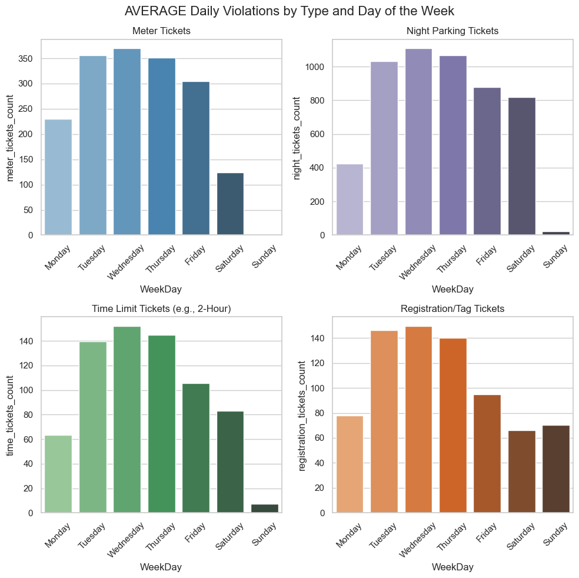

```python
# Group by weekday and calculate the mean (single average number for each day)  for each sub-count
sub_counts = ['meter_tickets_count', 'night_tickets_count', 'time_tickets_count', 'registration_tickets_count']
sub_counts_grouped = daily_summary_df.groupby('WeekDay')[sub_counts].mean().reindex(days_ordered).reset_index()

# Set up the 2x2 grid
fig, axes = plt.subplots(2, 2, figsize=(10, 10))
fig.suptitle('AVERAGE Daily Violations by Type and Day of the Week', fontsize=16)

# 1. Meter Tickets
sns.barplot(ax=axes[0, 0], data=sub_counts_grouped, x='WeekDay', y='meter_tickets_count', hue='WeekDay', palette='Blues_d')
axes[0, 0].set_title('Meter Tickets')
axes[0, 0].tick_params(axis='x', rotation=45)

# 2. Night Tickets
sns.barplot(ax=axes[0, 1], data=sub_counts_grouped, x='WeekDay', y='night_tickets_count', hue='WeekDay', palette='Purples_d')
axes[0, 1].set_title('Night Parking Tickets')
axes[0, 1].tick_params(axis='x', rotation=45)

# 3. Time Limit Tickets
sns.barplot(ax=axes[1, 0], data=sub_counts_grouped, x='WeekDay', y='time_tickets_count', hue='WeekDay', palette='Greens_d')
axes[1, 0].set_title('Time Limit Tickets (e.g., 2-Hour)')
axes[1, 0].tick_params(axis='x', rotation=45)

# 4. Registration Tickets
sns.barplot(ax=axes[1, 1], data=sub_counts_grouped, x='WeekDay', y='registration_tickets_count', hue='WeekDay', palette='Oranges_d')
axes[1, 1].set_title('Registration/Tag Tickets')
axes[1, 1].tick_params(axis='x', rotation=45)

plt.tight_layout()
plt.show()
```

```python
# Statistical Testing -- Violation subcount Features
# Testing to see if the (Temporal) Day of the Week significantly impacts the volume of these specific ticket violations
from scipy.stats import kruskal

print("--- STATISTICAL TESTING: Temporal Violation Sub-counts [min-targets] by Weekday ---")
results = {}

# meter_tickets_count, night_tickets_count, registration_tickets_count, time_tickets_count
for sub_count_col in sub_counts:
    groups = [daily_summary_df[daily_summary_df['WeekDay'] == day][sub_count_col] for day in days_ordered]
    stat, p_val = kruskal(*groups)

    print(f"{sub_count_col}_vs_WeekDay: Kruskal-Wallis H-statistic = {stat:.3f}, p-value = {p_val:.3g}")
```

```
--- STATISTICAL TESTING: Temporal Violation Sub-counts [min-targets] by Weekday ---
meter_tickets_count_vs_WeekDay: Kruskal-Wallis H-statistic = 1770.370, p-value = 0
night_tickets_count_vs_WeekDay: Kruskal-Wallis H-statistic = 1547.731, p-value = 0
time_tickets_count_vs_WeekDay: Kruskal-Wallis H-statistic = 1421.070, p-value = 6.64e-304
registration_tickets_count_vs_WeekDay: Kruskal-Wallis H-statistic = 886.000, p-value = 3.99e-188
```

### Weather Features

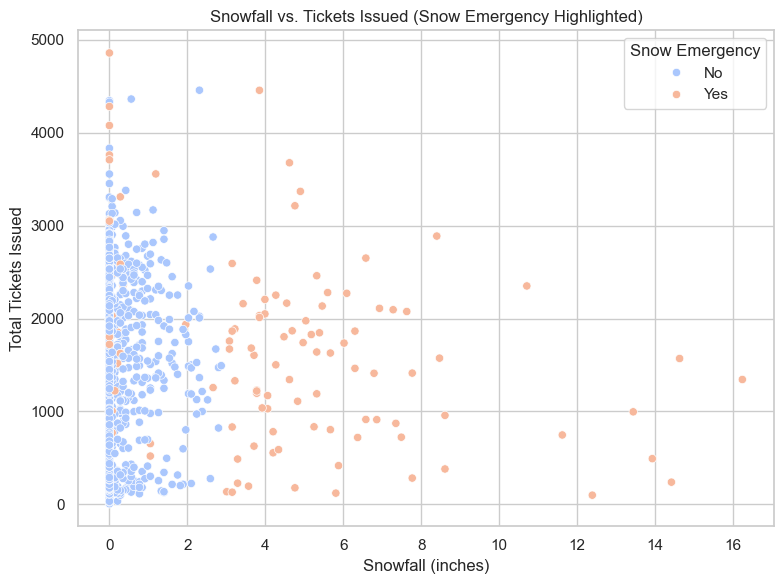

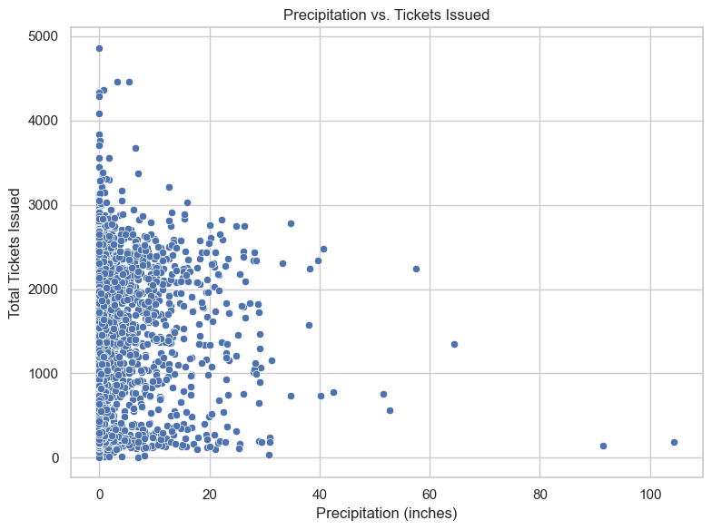

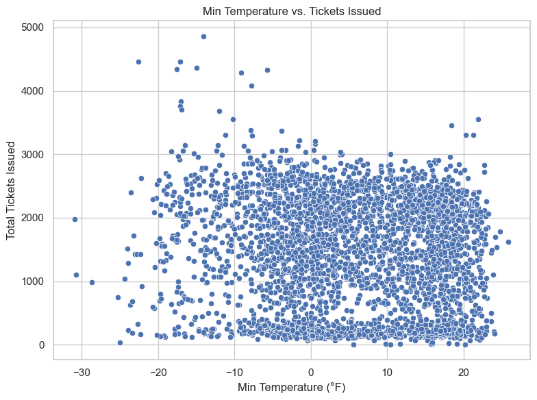

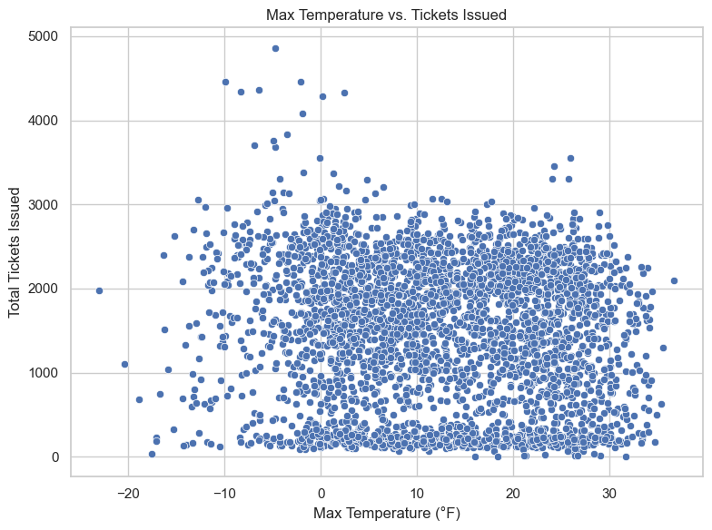

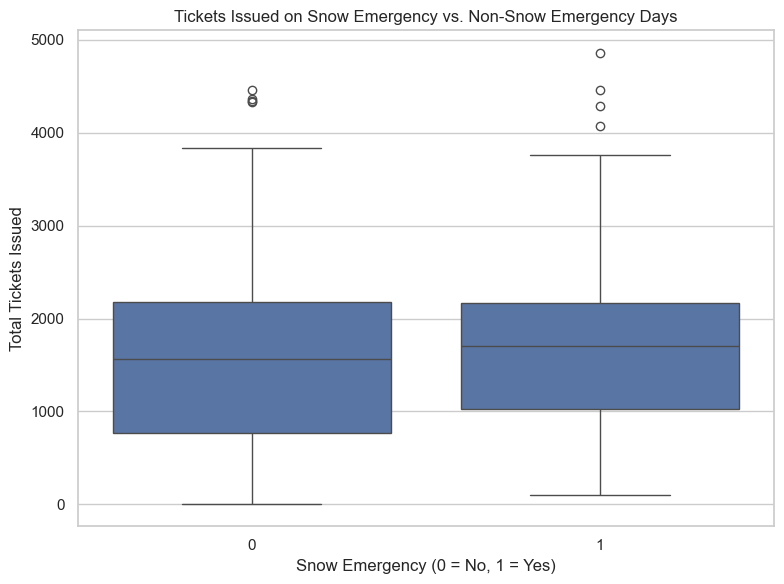

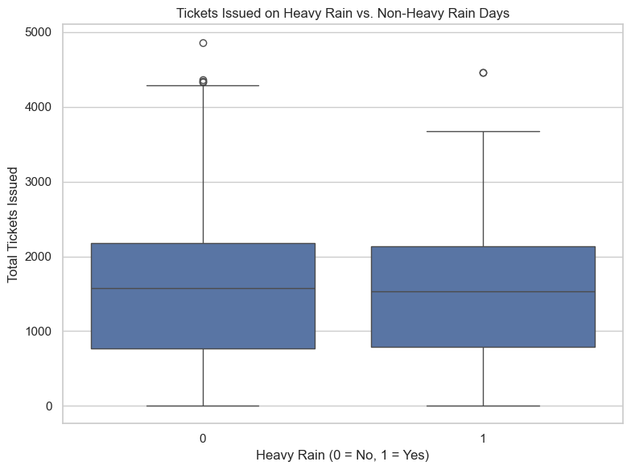

```python
# Weather and tickets issued: separate plots
import matplotlib.pyplot as plt
import seaborn as sns

daily_summary_df = daily_summary_df.copy()
daily_summary_df["snow_emergency_label"] = daily_summary_df["is_snow_emergency"].map({0: "No", 1: "Yes"})

# snowfall vs. tickets issued colored by snow emergency
plt.figure(figsize=(8, 6))
sns.scatterplot(
    data=daily_summary_df,
    x="snowfall",
    y="total_tickets",
    hue="snow_emergency_label",
    palette="coolwarm"
)
plt.title("Snowfall vs. Tickets Issued (Snow Emergency Highlighted)")
plt.xlabel("Snowfall (inches)")
plt.ylabel("Total Tickets Issued")
plt.legend(title="Snow Emergency")
plt.tight_layout()
plt.show()

# precipitation vs. tickets issued
plt.figure(figsize=(8, 6))
sns.scatterplot(
    data=daily_summary_df,
    x="precipitation",
    y="total_tickets"
)
plt.title("Precipitation vs. Tickets Issued")
plt.xlabel("Precipitation (inches)")
plt.ylabel("Total Tickets Issued")
plt.tight_layout()
plt.show()

# Min temp vs. tickets issued
plt.figure(figsize=(8, 6))
sns.scatterplot(
    data=daily_summary_df,
    x="min_temp",
    y="total_tickets"
)
plt.title("Min Temperature vs. Tickets Issued")
plt.xlabel("Min Temperature (°F)")
plt.ylabel("Total Tickets Issued")
plt.tight_layout()
plt.show()

# Max temp vs. tickets issued
plt.figure(figsize=(8, 6))
sns.scatterplot(
    data=daily_summary_df,
    x="max_temp",
    y="total_tickets"
)
plt.title("Max Temperature vs. Tickets Issued")
plt.xlabel("Max Temperature (°F)")
plt.ylabel("Total Tickets Issued")
plt.tight_layout()
plt.show()

# is_snow_emergency vs. tickets issued
plt.figure(figsize=(8, 6))
sns.boxplot(
    data=daily_summary_df,
    x="is_snow_emergency",
    y="total_tickets"
)
plt.title("Tickets Issued on Snow Emergency vs. Non-Snow Emergency Days")
plt.xlabel("Snow Emergency (0 = No, 1 = Yes)")
plt.ylabel("Total Tickets Issued")
plt.tight_layout()
plt.show()

# is_heavy_rain vs. tickets issued
plt.figure(figsize=(8, 6))
sns.boxplot(
    data=daily_summary_df,
    x="is_heavy_rain",
    y="total_tickets"
)
plt.title("Tickets Issued on Heavy Rain vs. Non-Heavy Rain Days")
plt.xlabel("Heavy Rain (0 = No, 1 = Yes)")
plt.ylabel("Total Tickets Issued")
plt.tight_layout()
plt.show()
```

```python
# spearman correlations
from scipy.stats import spearmanr

results = {}

# snowfall vs. tickets
corr, pval = spearmanr(daily_summary_df["snowfall"], daily_summary_df["total_tickets"])
results["snowfall_vs_tickets"] = (corr, pval)
results_total["snowfall_vs_tickets"] = (corr, pval)

# precipitation vs. tickets
corr, pval = spearmanr(daily_summary_df["precipitation"], daily_summary_df["total_tickets"])
results["precipitation_vs_tickets"] = (corr, pval)
results_total["precipitation_vs_tickets"] = (corr, pval)

# min temp vs. tickets
corr, pval = spearmanr(daily_summary_df["min_temp"], daily_summary_df["total_tickets"])
results["min_temp_vs_tickets"] = (corr, pval)
results_total["min_temp_vs_tickets"] = (corr, pval)

# max temp vs. tickets
corr, pval = spearmanr(daily_summary_df["max_temp"], daily_summary_df["total_tickets"])
results["max_temp_vs_tickets"] = (corr, pval)
results_total["max_temp_vs_tickets"] = (corr, pval)

for test, (corr, pval) in results.items():
    print(f"{test}: Spearman correlation = {corr:.3f}, p-value = {pval:.3g}")


# chi-squared test for is_snow_emergency vs. total_tickets (categorize total_tickets into bins for chi-squared)
from scipy.stats import chi2_contingency

# create contingency table for is_snow_emergency and binned total_tickets
daily_summary_df["tickets_bin"] = pd.cut(daily_summary_df["total_tickets"], bins=5)
contingency_table = pd.crosstab(daily_summary_df["is_snow_emergency"], daily_summary_df["tickets_bin"])
chi2, p, dof, expected = chi2_contingency(contingency_table)
print(f"Chi-squared test for Snow Emergency vs. Total Tickets (binned): chi2 = {chi2:.3f}, p-value = {p:.3g}")
results_total["is_snow_emergency_vs_tickets_chi2"] = (chi2, p)

# chi-squared test for is_heavy_rain vs. total_tickets (categorize total_tickets into bins for chi-squared)
# create contingency table for is_heavy_rain and binned total_tickets
contingency_table = pd.crosstab(daily_summary_df["is_heavy_rain"], daily_summary_df["tickets_bin"])
chi2, p, dof, expected = chi2_contingency(contingency_table)
print(f"Chi-squared test for Heavy Rain vs. Total Tickets (binned): chi2 = {chi2:.3f}, p-value = {p:.3g}")
results_total["is_heavy_rain_vs_tickets_chi2"] = (chi2, p)

# chi-squared test for is_snow_emergency_lag1 vs. total_tickets (categorize total_tickets into bins for chi-squared)
# create contingency table for is_snow_emergency_lag1 and binned total_tickets
contingency_table = pd.crosstab(daily_summary_df["is_snow_emergency_lag1"], daily_summary_df["tickets_bin"])
chi2, p, _, _ = chi2_contingency(contingency_table)
print(f"Chi-squared test for Snow Emergency (Lag 1) vs. Total Tickets (binned): chi2 = {chi2:.3f}, p-value = {p:.3g}")
results_total["is_snow_emergency_lag1_vs_tickets_chi2"] = (chi2, p)

# chi-squared test for is_snow_emergency_lag2 vs. total_tickets (categorize total_tickets into bins for chi-squared)
# create contingency table for is_snow_emergency_lag2 and binned total_tickets
contingency_table = pd.crosstab(daily_summary_df["is_snow_emergency_lag2"], daily_summary_df["tickets_bin"])
chi2, p, _, _ = chi2_contingency(contingency_table)
print(f"Chi-squared test for Snow Emergency (Lag 2) vs. Total Tickets (binned): chi2 = {chi2:.3f}, p-value = {p:.3g}")
results_total["is_snow_emergency_lag2_vs_tickets_chi2"] = (chi2, p)
```

```
snowfall_vs_tickets: Spearman correlation = 0.015, p-value = 0.401
precipitation_vs_tickets: Spearman correlation = -0.009, p-value = 0.625
min_temp_vs_tickets: Spearman correlation = -0.066, p-value = 0.000159
max_temp_vs_tickets: Spearman correlation = -0.093, p-value = 8.39e-08
Chi-squared test for Snow Emergency vs. Total Tickets (binned): chi2 = 62.235, p-value = 9.83e-13
Chi-squared test for Heavy Rain vs. Total Tickets (binned): chi2 = 2.223, p-value = 0.695
Chi-squared test for Snow Emergency (Lag 1) vs. Total Tickets (binned): chi2 = 112.176, p-value = 2.5e-23
Chi-squared test for Snow Emergency (Lag 2) vs. Total Tickets (binned): chi2 = 48.538, p-value = 7.29e-10
```

```python
# bonferroni correction for multiple testing (both temporal and weather features)
from statsmodels.stats.multitest import multipletests
# combine all p-values from both sets of tests in results_total
all_p_values = [p for _, p in results_total.values()]
# Apply Bonferroni correction
reject, pvals_corrected, _, _ = multipletests(all_p_values, method='bonferroni')
# map corrected p-values back to their respective tests
corrected_results = {}
for i, (test, (stat, p)) in enumerate(results_total.items()):
    corrected_results[test] = (stat, pvals_corrected[i], reject[i])
# print corrected results
print("Bonferroni Corrected Results")
for test, (stat, p_corr, reject) in corrected_results.items():
    print(f"{test}: statistic = {stat:.3f}, corrected p-value = {p_corr:.3g}, reject null: {reject}")
```

```
Bonferroni Corrected Results
WeekDay_vs_tickets: statistic = 1838.493, corrected p-value = 0, reject null: True
Month_vs_tickets: statistic = 61.101, corrected p-value = 8.68e-08, reject null: True
Year_vs_tickets: statistic = 387.142, corrected p-value = 1.58e-77, reject null: True
Day_vs_tickets: statistic = 21.845, corrected p-value = 1, reject null: False
is_weekend_vs_tickets: statistic = 348076.500, corrected p-value = 1.17e-205, reject null: True
is_holiday_vs_tickets: statistic = 129111.000, corrected p-value = 1.32e-19, reject null: True
is_sunday_vs_tickets: statistic = 55542.500, corrected p-value = 7.77e-221, reject null: True
snowfall_vs_tickets: statistic = 0.015, corrected p-value = 1, reject null: False
precipitation_vs_tickets: statistic = -0.009, corrected p-value = 1, reject null: False
min_temp_vs_tickets: statistic = -0.066, corrected p-value = 0.00238, reject null: True
max_temp_vs_tickets: statistic = -0.093, corrected p-value = 1.26e-06, reject null: True
is_snow_emergency_vs_tickets_chi2: statistic = 62.235, corrected p-value = 1.47e-11, reject null: True
is_heavy_rain_vs_tickets_chi2: statistic = 2.223, corrected p-value = 1, reject null: False
is_snow_emergency_lag1_vs_tickets_chi2: statistic = 112.176, corrected p-value = 3.75e-22, reject null: True
is_snow_emergency_lag2_vs_tickets_chi2: statistic = 48.538, corrected p-value = 1.09e-08, reject null: True
```

### co-linearity testing

```python
from statsmodels.stats.outliers_influence import variance_inflation_factor
import numpy as np
import pandas as pd

# one-hot encode WeekDay (drop_first to avoid dummy variable trap)
X = daily_summary_df.copy()
X = pd.get_dummies(X, columns=['WeekDay'], drop_first=True)

# select only the actual potential columns for VIF
vif_features_one_hot = [
    'rolling_30d_avg',
    'is_snow_emergency_lag1',
    'is_snow_emergency_lag2',
    'Month',
    'is_holiday',
    'is_weekend',
    'is_sunday',
    # plus all one-hot WeekDay columns automatically added
] + [col for col in X.columns if col.startswith('WeekDay_')]

vif_features_wav_encoding = [
    'rolling_30d_avg',
    'is_snow_emergency_lag1',
    'is_snow_emergency_lag2',
    'is_holiday',
    'is_sunday',
    'weekday_sin',
    'weekday_cos',
    'month_cos',
    'month_sin'
]


# drop rows with missing values in these columns
X_vif_one_hot = X[vif_features_one_hot].dropna()
X_vif_wav_encoding = X[vif_features_wav_encoding].dropna()
# convert all columns to float
X_vif_one_hot = X_vif_one_hot.astype(float)
X_vif_wav_encoding = X_vif_wav_encoding.astype(float)

X_vif_one_hot.info()
```

```
<class 'pandas.DataFrame'>
RangeIndex: 3257 entries, 30 to 3286
Data columns (total 14 columns):
 #   Column                  Non-Null Count  Dtype
---  ------                  --------------  -----
 0   rolling_30d_avg         3257 non-null   float64
 1   is_snow_emergency_lag1  3257 non-null   float64
 2   is_snow_emergency_lag2  3257 non-null   float64
 3   Month                   3257 non-null   float64
 4   is_holiday              3257 non-null   float64
 5   is_weekend              3257 non-null   float64
 6   is_sunday               3257 non-null   float64
 7   WeekDay_num             3257 non-null   float64
 8   WeekDay_Monday          3257 non-null   float64
 9   WeekDay_Saturday        3257 non-null   float64
 10  WeekDay_Sunday          3257 non-null   float64
 11  WeekDay_Thursday        3257 non-null   float64
 12  WeekDay_Tuesday         3257 non-null   float64
 13  WeekDay_Wednesday       3257 non-null   float64
dtypes: float64(14)
memory usage: 356.4 KB
```

```python
# calculate VIF for each feature
vif_df_one_hot = pd.DataFrame({
    'feature': X_vif_one_hot.columns,
    'VIF': [variance_inflation_factor(X_vif_one_hot.values, i) for i in range(X_vif_one_hot.shape[1])]
})
print(vif_df_one_hot)

vif_df_wav_encoding = pd.DataFrame({
    'feature': X_vif_wav_encoding.columns,
    'VIF': [variance_inflation_factor(X_vif_wav_encoding.values, i) for i in range(X_vif_wav_encoding.shape[1])]
})
print(vif_df_wav_encoding)
```

```
                   feature        VIF
0          rolling_30d_avg   1.042547
1   is_snow_emergency_lag1   1.074930
2   is_snow_emergency_lag2   1.076911
3                    Month   1.044046
4               is_holiday   1.020558
5               is_weekend        inf
6                is_sunday        inf
7              WeekDay_num  23.524609
8           WeekDay_Monday   3.862594
9         WeekDay_Saturday        inf
10          WeekDay_Sunday        inf
11        WeekDay_Thursday   1.759013
12         WeekDay_Tuesday   2.598177
13       WeekDay_Wednesday   1.975596
                  feature       VIF
0         rolling_30d_avg  1.358170
1  is_snow_emergency_lag1  1.142116
2  is_snow_emergency_lag2  1.143461
3              is_holiday  1.061444
4               is_sunday  1.729743
5             weekday_sin  1.297860
6             weekday_cos  1.208720
7               month_cos  1.031049
8               month_sin  1.018980
```

### Modeling & Validation

```python
# loop for Negative Binomial regression with rolling window cross-validation
import numpy as np
import pandas as pd
from statsmodels.discrete.discrete_model import NegativeBinomial
from sklearn.model_selection import TimeSeriesSplit
from sklearn.metrics import mean_squared_error

# features to use
features = [
    'is_holiday', 'is_sunday',
    'is_snow_emergency_lag1',
    'is_snow_emergency_lag2',
    'rolling_30d_avg',
    'month_sin', 'month_cos', 'weekday_sin', 'weekday_cos'
    ]
# with one hot encoded WeekDay & month
# get dummy variables for WeekDay and Month (drop_first to avoid dummy variable trap)
# daily_summary_df = pd.get_dummies(daily_summary_df, columns=['WeekDay'], drop_first=True)
# daily_summary_df = pd.get_dummies(daily_summary_df, columns=['Month'], drop_first=True)
# features = [
#     'is_holiday', 'is_weekend',
#     'is_snow_emergency_lag1', 'is_snow_emergency_lag2',
#     'rolling_30d_avg', 'WeekDay_Friday', 'WeekDay_Monday',
#     'WeekDay_Saturday', 'WeekDay_Sunday', 'WeekDay_Thursday', 'WeekDay_Tuesday', 'WeekDay_Wednesday']
target = 'total_tickets'

# drop 2020 (COVID-19 pandemic year) to avoid instability due to abnormal enforcement patterns?
model_df = daily_summary_df[daily_summary_df['Year'] != 2020].dropna(subset=features + [target]).copy()

# rolling window cross-validation
n_splits = 8
window_size = int(len(model_df) / (n_splits + 1))  # size of each training window (e.g., 1 year if data is daily and we want 8 folds)

pearson_stats = []
deviance_stats = []
nmse_scores = []  # normalized MSE
loss_values = []  # final loss function value for each window

# prepare a column for predictions (initialize with NaN)
daily_summary_df['predicted_tickets'] = np.nan

for i in range(n_splits):
    train_start = i * window_size
    train_end = train_start + window_size
    test_start = train_end
    test_end = test_start + window_size

    train = model_df.iloc[train_start:train_end]
    test = model_df.iloc[test_start:test_end]

    if len(test) == 0:
        break

    X_train = train[features]
    y_train = train[target]
    X_test = test[features]
    y_test = test[target]

    # Add intercept
    import statsmodels.api as sm
    X_train_const = sm.add_constant(X_train)
    X_test_const = sm.add_constant(X_test)

    # fit Negative Binomial model (with intercept)
    model = NegativeBinomial(y_train, X_train_const)
    result = model.fit(disp=0)
    y_pred = result.predict(X_test_const)

    # save the final loss function value (negative log-likelihood)
    loss_values.append(result.llf)

    # debugging print if y_pred has nans
    # The predicted_tickets column is NaN for the first year because of how rolling window cross-validation is set up

    if np.isnan(y_pred).any():
        print(f"Warning: NaNs detected in y_pred for fold {i+1}. Indices: {np.where(np.isnan(y_pred))[0]}")

    # remove any rows where y_test or y_pred is NaN
    valid_idx = ~(np.isnan(y_test) | np.isnan(y_pred))
    y_test_valid = y_test[valid_idx]
    y_pred_valid = y_pred[valid_idx]
    if len(y_test_valid) == 0:
        print(f"All predictions or targets are NaN for fold {i+1}, skipping this fold.")
        continue  # skip this fold if all values are NaN

    # pearson statistic
    mu = y_pred_valid
    alpha = result.params.get('alpha', result.scale)  # fallback if alpha not in params
    var = mu + alpha * mu**2
    pearson = np.sum((y_test_valid - mu) ** 2 / var)
    pearson_stats.append(pearson / len(y_test_valid))

    # deviance statistic (Negative Binomial deviance)
    y = y_test_valid.values
    mu = mu.values if hasattr(mu, 'values') else mu
    eps = 1e-10  # avoid log(0)
    deviance = 2 * np.sum(
    y * np.log((y + eps) / (mu + eps)) - (y + 1/alpha) * np.log((1 + alpha * y + eps) / (1 + alpha * mu + eps))
    )
    deviance_stats.append(deviance / len(y_test_valid))

    # Normalized MSE (NMSE)
    mse = mean_squared_error(y_test_valid, y_pred_valid)
    nmse = mse / np.mean(y_test_valid ** 2)
    nmse_scores.append(nmse)

    # pearsons r as a sanity check?

    # write predictions into the original dataframe for the test period
    # update predicted_tickets for the test dates
    test_dates = test['join_date']
    daily_summary_df.loc[daily_summary_df['join_date'].isin(test_dates), 'negative_binomial_predicted_tickets'] = y_pred.values

print(f"Rolling window Negative Binomial regression results (n_splits={n_splits}):")
for i, (p, d, nmse, loss) in enumerate(zip(pearson_stats, deviance_stats, nmse_scores, loss_values), 1):
    print(f"Fold {i}: Pearson/df = {p:.2f}, Deviance/df = {d:.2f}, NMSE = {nmse:.4f}, Final Log-Likelihood = {loss:.2f}")

# now take 2022-2023 as the held out test set and fit the model on all prior data to see how it performs on the most recent data
# still drop covid year 2020 from training to avoid instability
train_final = model_df[model_df['Year'] < 2022]
test_final = daily_summary_df[daily_summary_df['Year'] >= 2022].copy()
X_train_final = train_final[features]
y_train_final = train_final[target]
X_test_final = test_final[features]
y_test_final = test_final[target]
# Add intercept
X_train_final_const = sm.add_constant(X_train_final)
X_test_final_const = sm.add_constant(X_test_final)

# fit final model
final_model = NegativeBinomial(y_train_final, X_train_final_const)
final_result = final_model.fit(disp=0)
y_pred_final = final_result.predict(X_test_final_const)
# evaluate final model on held-out test set
final_loss = final_result.llf

# save final predictions into the original dataframe for the test period
test_final_dates = test_final['join_date']
daily_summary_df.loc[daily_summary_df['join_date'].isin(test_final_dates), 'negative_binomial_predicted_tickets'] = y_pred_final.values


alpha = final_result.params.get('alpha', 0.1) # Default to 0.1 or similar if not found
eps = 1e-10

# final Pearson
mu_final = y_pred_final
var_final = mu_final + alpha * mu_final**2
final_pearson = np.sum((y_test_final - mu_final) ** 2 / var_final) / len(y_test_final)
term1 = y_test_final * np.log((y_test_final + eps) / (mu_final + eps))
term2 = (y_test_final + 1/alpha) * np.log((1 + alpha * y_test_final + eps) / (1 + alpha * mu_final + eps))
final_deviance = 2 * np.sum(term1 - term2) / len(y_test_final)
final_nmse = mean_squared_error(y_test_final, y_pred_final) / np.mean(y_test_final ** 2)
print(f"Final model performance on held-out test set (2022-2023): Pearson/df = {final_pearson:.2f}, Deviance/df = {final_deviance:.2f}, NMSE = {final_nmse:.4f}, Log-Likelihood = {final_loss:.2f}")
```

```
Rolling window Negative Binomial regression results (n_splits=8):
Fold 1: Pearson/df = 1.13, Deviance/df = 1.66, NMSE = 0.0399, Final Log-Likelihood = -2310.48
Fold 2: Pearson/df = 1.07, Deviance/df = 1.54, NMSE = 0.0426, Final Log-Likelihood = -2333.68
Fold 3: Pearson/df = 1.40, Deviance/df = 1.04, NMSE = 0.0393, Final Log-Likelihood = -2378.98
Fold 4: Pearson/df = 14.44, Deviance/df = 2.99, NMSE = 0.0899, Final Log-Likelihood = -2348.80
Fold 5: Pearson/df = 0.75, Deviance/df = 0.96, NMSE = 0.1325, Final Log-Likelihood = -2455.70
Fold 6: Pearson/df = 1.08, Deviance/df = 1.86, NMSE = 0.1756, Final Log-Likelihood = -2397.99
Fold 7: Pearson/df = 0.78, Deviance/df = 1.05, NMSE = 0.0662, Final Log-Likelihood = -2392.63
Fold 8: Pearson/df = 0.89, Deviance/df = 1.08, NMSE = 0.0740, Final Log-Likelihood = -2334.66
Final model performance on held-out test set (2022-2023): Pearson/df = 0.72, Deviance/df = 1.00, NMSE = 0.0670, Log-Likelihood = -19005.18
```

```python
# model.summary()
# model_df.head()
daily_summary_df = daily_summary_df.sort_values('join_date').reset_index(drop=True)
```

```python
# Build Poisson Regression Model (as a baseline to Negative Binomial) with the same features and rolling window cross-validation
import numpy as np
import pandas as pd
import statsmodels.api as sm
from sklearn.metrics import mean_squared_error

print("--- POISSON REGRESSION (BASELINE COMPARISON) ---")

# Using  exact same feature set and target

# Drop 2020
model_df = daily_summary_df[daily_summary_df['Year'] != 2020].dropna(subset=features + [target]).copy()

n_splits = 8
window_size = int(len(model_df) / (n_splits + 1))

poisson_pearson_stats = []  # Pearson goodness-of-fit statistic (not r)
poisson_deviance_stats = []
poisson_nmse_scores = []
poisson_loss_values = []
poisson_r_scores = []  # Pearson correlation coefficient (r)

# Make a column for POISSON predictions
daily_summary_df['poisson_predicted_tickets'] = np.nan

for i in range(n_splits):
    train_start = i * window_size
    train_end = train_start + window_size
    test_start = train_end
    test_end = test_start + window_size

    train = model_df.iloc[train_start:train_end]
    test = model_df.iloc[test_start:test_end]

    if len(test) == 0:
        break

    X_train_const = sm.add_constant(train[features])
    y_train = train[target]
    X_test_const = sm.add_constant(test[features])
    y_test = test[target]

    # Fit the standard Poisson GLM
    poisson_model = sm.GLM(y_train, X_train_const, family=sm.families.Poisson())
    result = poisson_model.fit()
    y_pred = result.predict(X_test_const)

    poisson_loss_values.append(result.llf)

    valid_idx = ~(np.isnan(y_test) | np.isnan(y_pred))
    y_test_valid, y_pred_valid = y_test[valid_idx], y_pred[valid_idx]

    if len(y_test_valid) == 0:
        continue

    # Calculate stats using statsmodels built-in properties for GLM
    # Divide by degrees of freedom to match  Pearson/df output
    df_resid = len(y_test_valid) - X_test_const.shape[1]

    # For out-of-sample deviance/pearson, calculate manually:
    mu = y_pred_valid
    y = y_test_valid

    # Poisson Pearson: Sum( (y - mu)^2 / mu )
    pearson = np.sum((y - mu)**2 / mu)
    poisson_pearson_stats.append(pearson / df_resid)

    # Poisson Deviance: 2 * Sum( y * log(y/mu) - (y - mu) )
    eps = 1e-10
    deviance = 2 * np.sum(y * np.log((y + eps) / (mu + eps)) - (y - mu))
    poisson_deviance_stats.append(deviance / df_resid)

    # NMSE
    mse = mean_squared_error(y_test_valid, y_pred_valid)
    poisson_nmse_scores.append(mse / np.mean(y_test_valid ** 2))

    # Pearson correlation coefficient (r) between actual and predicted
    from scipy.stats import pearsonr
    r, r_p = pearsonr(y_test_valid, y_pred_valid)
    poisson_r_scores.append(r)

    # # Save predictions
    test_dates = test['join_date']
    daily_summary_df.loc[daily_summary_df['join_date'].isin(test_dates), 'poisson_predicted_tickets'] = y_pred.values

print(f"Rolling window POISSON regression results (n_splits={n_splits}):")
for i, (p, d, nmse, loss, r) in enumerate(zip(poisson_pearson_stats, poisson_deviance_stats, poisson_nmse_scores, poisson_loss_values, poisson_r_scores), 1):
    print(f"Fold {i}: Pearson/df = {p:.2f}, Deviance/df = {d:.2f}, NMSE = {nmse:.4f}, Final Log-Likelihood = {loss:.2f}, Pearson r = {r:.3f}")

# Fit final Poisson model on all data prior to 2022 and evaluate on 2022-2023 held-out test set
train_final = model_df[model_df['Year'] < 2022]
test_final = daily_summary_df[daily_summary_df['Year'] >= 2022].copy()
X_train_final_const = sm.add_constant(train_final[features])
y_train_final = train_final[target]
X_test_final_const = sm.add_constant(test_final[features])
y_test_final = test_final[target]
poisson_final_model = sm.GLM(y_train_final, X_train_final_const, family=sm.families.Poisson())
poisson_final_result = poisson_final_model.fit()
y_pred_final = poisson_final_result.predict(X_test_final_const)

# save final predictions
test_final_dates = test_final['join_date']
daily_summary_df.loc[daily_summary_df['join_date'].isin(test_final['join_date']), 'poisson_predicted_tickets'] = y_pred_final.values

final_loss = poisson_final_result.llf
df_resid = len(y_test_final) - X_test_final_const.shape[1]
mu = y_pred_final
y = y_test_final
final_pearson = np.sum((y - mu)**2 / mu) / df_resid
eps = 1e-10
final_deviance = 2 * np.sum(y * np.log((y + eps) / (mu + eps)) - (y - mu)) / df_resid
final_nmse = mean_squared_error(y_test_final, y_pred_final) / np.mean(y_test_final ** 2)
final_r, _ = pearsonr(y_test_final, y_pred_final)
print(f"Final POISSON model performance on held-out test set (2022-2023): Pearson/df = {final_pearson:.2f}, Deviance/df = {final_deviance:.2f}, NMSE = {final_nmse:.4f}, Pearson r = {final_r:.3f}, Log-Likelihood = {final_loss:.2f}")
```

```
--- POISSON REGRESSION (BASELINE COMPARISON) ---
Rolling window POISSON regression results (n_splits=8):
Fold 1: Pearson/df = 82.58, Deviance/df = 92.89, NMSE = 0.0402, Final Log-Likelihood = -11107.17, Pearson r = 0.891
Fold 2: Pearson/df = 89.17, Deviance/df = 103.86, NMSE = 0.0417, Final Log-Likelihood = -14078.01, Pearson r = 0.895
Fold 3: Pearson/df = 96.65, Deviance/df = 93.63, NMSE = 0.0382, Final Log-Likelihood = -16503.33, Pearson r = 0.895
Fold 4: Pearson/df = 433.88, Deviance/df = 214.47, NMSE = 0.0880, Final Log-Likelihood = -14090.17, Pearson r = 0.770
Fold 5: Pearson/df = 152.94, Deviance/df = 163.62, NMSE = 0.0799, Final Log-Likelihood = -30130.97, Pearson r = 0.783
Fold 6: Pearson/df = 159.01, Deviance/df = 194.32, NMSE = 0.1000, Final Log-Likelihood = -23630.34, Pearson r = 0.790
Fold 7: Pearson/df = 116.43, Deviance/df = 130.99, NMSE = 0.0660, Final Log-Likelihood = -23270.40, Pearson r = 0.851
Fold 8: Pearson/df = 101.53, Deviance/df = 113.64, NMSE = 0.0662, Final Log-Likelihood = -18323.27, Pearson r = 0.848
Final POISSON model performance on held-out test set (2022-2023): Pearson/df = 103.28, Deviance/df = 124.40, NMSE = 0.0679, Pearson r = 0.852, Log-Likelihood = -167112.71
```

## Results Graphics

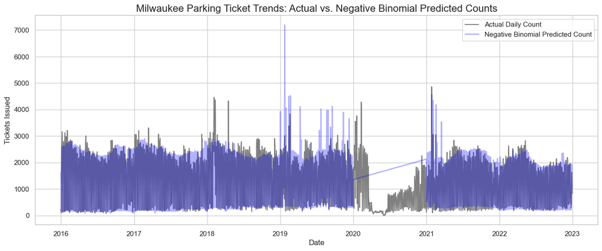

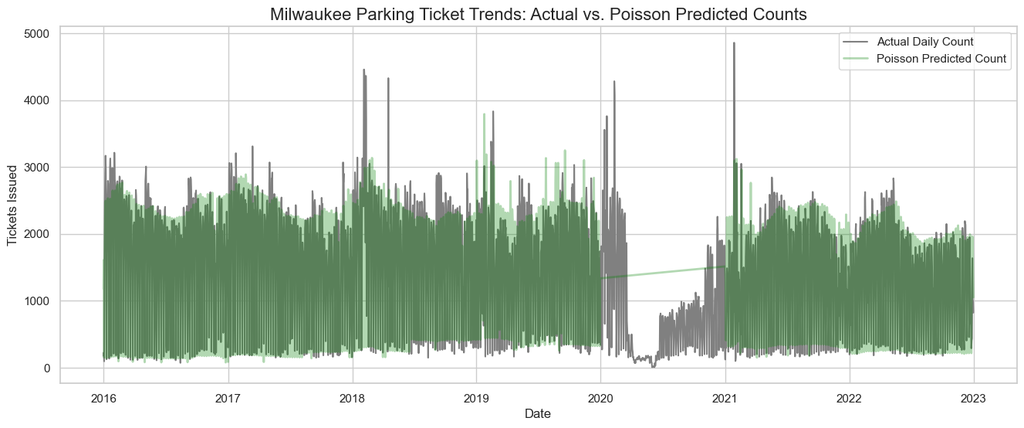

```python
# overlay the logged prediction counts with the actual daily ticket values
# this didnt work very well
import matplotlib.pyplot as plt
import seaborn as sns
import numpy as np


# plot actual daily counts and overlay predicted counts
plt.figure(figsize=(16, 6))
plot_df = daily_summary_df[daily_summary_df['Year'] >= 2016]
sns.lineplot(data=plot_df, x='join_date', y='total_tickets', color='gray', label='Actual Daily Count')
sns.lineplot(data=plot_df, x='join_date', y='negative_binomial_predicted_tickets', color='blue', alpha=0.3, linewidth=2, label='Negative Binomial Predicted Count')

plt.title("Milwaukee Parking Ticket Trends: Actual vs. Negative Binomial Predicted Counts", fontsize=16)
plt.xlabel("Date")
plt.ylabel("Tickets Issued")
plt.legend()
plt.show()

# do the same for the Poisson predictions
plt.figure(figsize=(16, 6))
plot_df = daily_summary_df[daily_summary_df['Year'] >= 2016]
sns.lineplot(data=plot_df, x='join_date', y='total_tickets', color='gray', label='Actual Daily Count')
sns.lineplot(data=plot_df, x='join_date', y='poisson_predicted_tickets', color='green', alpha=0.3, linewidth=2, label='Poisson Predicted Count')
plt.title("Milwaukee Parking Ticket Trends: Actual vs. Poisson Predicted Counts", fontsize=16)
plt.xlabel("Date")
plt.ylabel("Tickets Issued")
plt.legend()
plt.show()
```

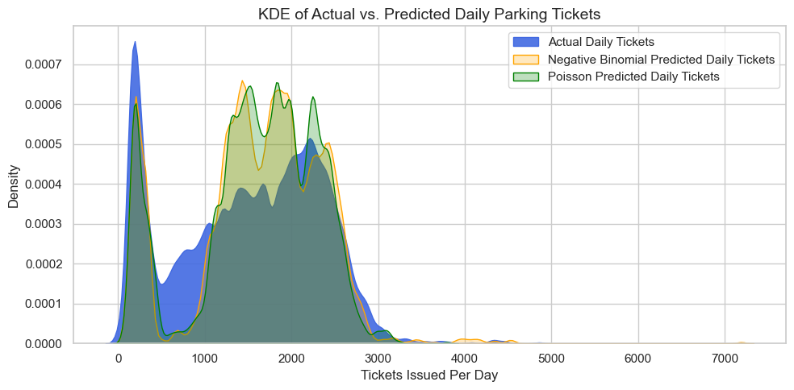

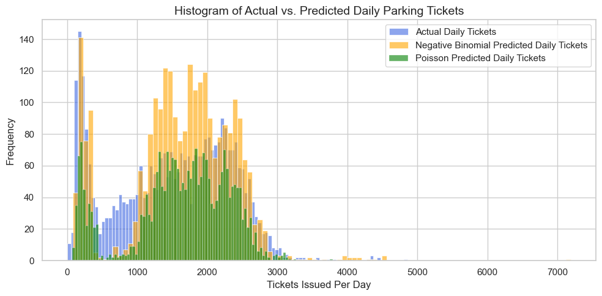

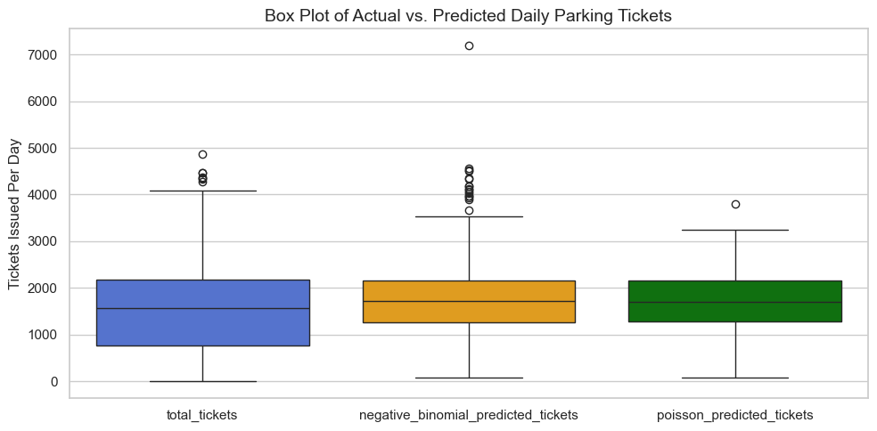

```python
# overlay KDE plot for actual vs. predicted daily ticket counts for both models
plt.figure(figsize=(10, 5))
sns.kdeplot(daily_summary_df['total_tickets'].dropna(), bw_adjust=.3, fill=True, color='royalblue', alpha=0.9, label='Actual Daily Tickets')
sns.kdeplot(daily_summary_df['negative_binomial_predicted_tickets'].dropna(),bw_adjust=.3, fill=True, color='orange', label='Negative Binomial Predicted Daily Tickets')
sns.kdeplot(daily_summary_df['poisson_predicted_tickets'].dropna(), bw_adjust=.3, fill=True, color='green', label='Poisson Predicted Daily Tickets')
plt.title('KDE of Actual vs. Predicted Daily Parking Tickets', fontsize=14)
plt.xlabel('Tickets Issued Per Day')
plt.ylabel('Density')
plt.legend()
plt.tight_layout()
plt.show()

# do histogram of the count data to prevent smoothing out the count nature of the data with KDE
plt.figure(figsize=(10, 5))
sns.histplot(daily_summary_df['total_tickets'].dropna(), bins=100, color='royalblue', alpha=0.6, label='Actual Daily Tickets')
sns.histplot(daily_summary_df['negative_binomial_predicted_tickets'].dropna(), bins=100, color='orange', alpha=0.6, label='Negative Binomial Predicted Daily Tickets')
sns.histplot(daily_summary_df['poisson_predicted_tickets'].dropna(), bins=100, color='green', alpha=0.6, label='Poisson Predicted Daily Tickets')
plt.title('Histogram of Actual vs. Predicted Daily Parking Tickets', fontsize=14)
plt.xlabel('Tickets Issued Per Day')
plt.ylabel('Frequency')
plt.legend()
plt.tight_layout()
plt.show()

# box plot of actual vs. predicted daily ticket counts for both models
plt.figure(figsize=(10, 5))
sns.boxplot(data=daily_summary_df[['total_tickets', 'negative_binomial_predicted_tickets', 'poisson_predicted_tickets']].melt(var_name='Type', value_name='Tickets'), x='Type', y='Tickets', palette=['royalblue', 'orange', 'green'])
plt.title('Box Plot of Actual vs. Predicted Daily Parking Tickets', fontsize=14)
plt.xlabel('')
plt.ylabel('Tickets Issued Per Day')
plt.tight_layout()
plt.show()
```

```python
daily_summary_df.sample(8)
```

|  | join_date | total_tickets | max_temp | min_temp | precipitation | snowfall | is_snow_emergency | is_heavy_rain | WeekDay | Year | ... | weekday_sin | weekday_cos | day_sin | day_cos | rolling_30d_avg | snow_emergency_label | tickets_bin | predicted_tickets | negative_binomial_predicted_tickets | poisson_predicted_tickets |
| --- | --- | --- | --- | --- | --- | --- | --- | --- | --- | --- | --- | --- | --- | --- | --- | --- | --- | --- | --- | --- | --- |
| 675 | 2015-11-07 | 1213 | 8.9 | 5.8 | 0.0 | 0.00 | 0 | 0 | Saturday | 2015 | ... | -0.974928 | -0.222521 | 0.988468 | 0.151428 | 0.616963 | No | (977.4, 1947.8] | NaN | 1596.516303 | 1589.244134 |
| 2811 | 2021-09-12 | 197 | 23.3 | 16.4 | 21.8 | 0.00 | 0 | 1 | Sunday | 2021 | ... | -0.781831 | 0.623490 | 0.651372 | -0.758758 | 0.532796 | No | (2.148, 977.4] | NaN | 356.769289 | 347.143412 |
| 1633 | 2018-06-22 | 2114 | 15.5 | 12.1 | 12.9 | 0.00 | 0 | 1 | Friday | 2018 | ... | -0.433884 | -0.900969 | -0.968077 | -0.250653 | 0.655087 | No | (1947.8, 2918.2] | NaN | 1782.677586 | 1757.093615 |
| 3211 | 2022-10-17 | 548 | 5.9 | 1.2 | 0.3 | 0.14 | 0 | 0 | Monday | 2022 | ... | 0.000000 | 1.000000 | -0.299363 | -0.954139 | 0.441622 | No | (2.148, 977.4] | NaN | 1102.877154 | 1165.144540 |
| 513 | 2015-05-29 | 2193 | 18.4 | 14.3 | 7.6 | 0.00 | 0 | 1 | Friday | 2015 | ... | -0.433884 | -0.900969 | -0.394356 | 0.918958 | 0.707407 | No | (1947.8, 2918.2] | NaN | 1903.918196 | 1869.252790 |
| 2411 | 2020-08-08 | 317 | 31.2 | 19.0 | 1.1 | 0.00 | 0 | 0 | Saturday | 2020 | ... | -0.974928 | -0.222521 | 0.998717 | -0.050649 | 0.197384 | No | (2.148, 977.4] | NaN | NaN | NaN |
| 1327 | 2017-08-20 | 202 | 30.0 | 17.0 | 0.0 | 0.00 | 0 | 0 | Sunday | 2017 | ... | -0.781831 | 0.623490 | -0.790776 | -0.612106 | 0.552058 | No | (2.148, 977.4] | NaN | 231.089076 | 222.823273 |
| 3272 | 2022-12-17 | 1201 | -1.5 | -6.2 | 0.7 | 0.49 | 0 | 0 | Saturday | 2022 | ... | -0.974928 | -0.222521 | -0.299363 | -0.954139 | 0.445697 | No | (977.4, 1947.8] | NaN | 1164.570268 | 1104.352983 |

8 rows × 34 columns